# A global meta-analysis of greenhouse gases emission and crop yield under no-tillage as compared to conventional tillage - ScienceDirect

[Register](https://www.sciencedirect.com/user/register?targetURL=%2Fscience%2Farticle%2Fpii%2FS0048969720358289)[Sign in](https://www.sciencedirect.com/user/login?targetURL=%2Fscience%2Farticle%2Fpii%2FS0048969720358289)

[Advanced](https://www.sciencedirect.com/search)

## Outline

1. Highlights
2. Abstract
3. Graphical abstract
4. Keywords
5. 1. Introduction
6. 2. Materials and methods
7. 3. Results
8. 4. Discussion
9. 5. Limitations
10. 6. Conclusions
11. CRediT authorship contribution statement
12. Declaration of competing interest
13. Acknowledgments
14. References

## Figures (8)

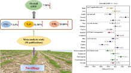

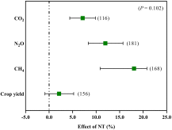

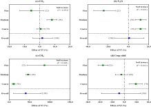

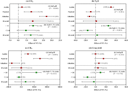

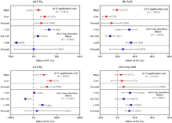

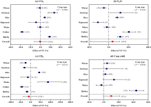

## Tables (2)

1. Table 1
2. Table 2

## [Science of The Total Environment](https://www.sciencedirect.com/science/journal/00489697)

[Volume 750](https://www.sciencedirect.com/science/journal/00489697/750/supp/C), 1 January 2021, 142299

# A global meta-analysis of greenhouse gases emission and crop yield under no-tillage as compared to conventional tillage

[AwaisShakoor<sup>a</sup>](https://www.sciencedirect.com/science/article/pii/S0048969720358289#!)[MuhammadShahbaz<sup>b</sup>](https://www.sciencedirect.com/science/article/pii/S0048969720358289#!)[Taimoor HassanFarooq<sup>c</sup>](https://www.sciencedirect.com/science/article/pii/S0048969720358289#!)[Najam E.Sahar<sup>d</sup>](https://www.sciencedirect.com/science/article/pii/S0048969720358289#!)[Sher MuhammadShahzad<sup>e</sup>](https://www.sciencedirect.com/science/article/pii/S0048969720358289#!)[Muhammad MohsinAltaf<sup>f</sup>](https://www.sciencedirect.com/science/article/pii/S0048969720358289#!)[MuhammadAshraf<sup>g</sup>](https://www.sciencedirect.com/science/article/pii/S0048969720358289#!)

https://doi.org/10.1016/j.scitotenv.2020.142299[Get rights and content](https://s100.copyright.com/AppDispatchServlet?publisherName=ELS&contentID=S0048969720358289&orderBeanReset=true)

## Highlights

**•**

Fifty peer-reviewed publications were used to conduct a global meta-analysis.

**•**

**•**

Overall, NT significantly reduced GWP by 7.56% as compared to (conventional tillage) CT.

**•**

In NT, barley and wheat yields increased by 43.76% and 4.49%, respectively.

## Graphical abstract

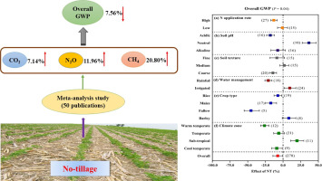

1. [Download : Download high-res image (258KB)](https://ars.els-cdn.com/content/image/1-s2.0-S0048969720358289-ga1_lrg.jpg)
2. [Download : Download full-size image](https://ars.els-cdn.com/content/image/1-s2.0-S0048969720358289-ga1.jpg)
- [**Previous** article in issue](https://www.sciencedirect.com/science/article/pii/S0048969720358095)
- [**Next** article in issue](https://www.sciencedirect.com/science/article/pii/S0048969720358526)

## Keywords

Crop yield

GHGs emission

No-tillage

Meta-analysis

Mitigation

## 1. Introduction

Global warming is one of the major consequences of the human activities associated with increasing concentration of atmospheric greenhouse gases (GHGs) emission, such as carbon dioxide (CO<sub>2</sub>), methane (CH<sub>4</sub>), nitrous oxide (N<sub>2</sub>O) (Paustian et al., 2006). Among anthropogenic activities, agriculture is estimated to be accountable for 12% of total GHGs emissions (IPCC, 2014). This reveals the importance of agricultural management practices, particularly soil tillage, in emitting or mitigating GHGs emission (WRI, 2014). Soil stores 3–4 times more carbon (C) than is present in vegetation and atmosphere combined (Lal, 2004a). Total C in the terrestrial environment is ~3170 Pg and nearly 80% (2500 Pg) of this C is found in topsoil (Jobbagy and Jackson, 2000; Lal, 2004b, Lal, 2008). Soil C and nitrogen (N) cycles are closely interlinked and controlled by different biological processes (Martínez et al., 2017). The decomposition of soil organic matter (SOM) through biological processes is a key part of both C and N cycles. Therefore, any change or disturbance in SOM decomposition would have direct impact on GHGs emission such as CO<sub>2</sub>, CH<sub>4</sub>, and N<sub>2</sub>O and thus global warming (Shakoor et al., 2020b). No-tillage (NT) as compared to conventional tillage (CT) is becoming popular with an aim to improve soil C sequestration, soil physiochemical conditions without compromising crop yield (Lal, 2015; Lal et al., 2007). In addition, NT management practice can also significantly alter the concentrations of GHGs emissions from agricultural soils. However, net effect of NT on GHGs emissions and crop yields remains variable.

Worldwide, NT was practiced on ~111 million ha land in 2009 (Derpsch et al., 2010), and in 2014, this number touched ~155 million ha (Huang et al., 2018). No-tillage is extensively used to protect soil degradation and erosion (Krauss et al., 2017), to improve soil aggregation ability (Quiroga et al., 2010), to increase SOM stocks (Stewart et al., 2016) and to mitigate the GHGs emissions (Kong et al., 2009) as compared to CT practice.

The effects of NT on GHGs emissions have been intensively debated and ominously vary among individual research studies (Abdalla et al., 2016; Van Kessel et al., 2013; Zhao et al., 2016). Previous research studies showed that NT, as compared to CT, significantly increased (Sainju, 2016; Zhang et al., 2016; Z.S. Zhang et al., 2016; D. Zhang et al., 2016; G. Zhang et al., 2016), decreased (Lu et al., 2016; Tellez-Rio et al., 2015b) and/or did not affect (Bayer et al., 2015) CO<sub>2</sub>, CH<sub>4</sub>, and N<sub>2</sub>O emissions from agricultural soils. The high inconsistency in the results from individual studies are challenging to reveal the main effect of soil tillage on GHGs mitigation. Though some research studies have been conducted to evaluate the effect of NT as compared to CT on GHG mitigation, but they only focused on N<sub>2</sub>O and/or CH<sub>4</sub> emissions (Van Kessel et al., 2013; Zhao et al., 2016). The effect of NT on the global warming potential (GWP) of GHGs emissions has not also been well addressed, keeping GHGs mitigation possibilities with NT indeterminate.

Different hypotheses have been suggested to describe the GHGs emissions in responses to NT as compared to CT. For example, it is estimated that SOM decomposition is significantly affected by soil tillage (Lal, 2003). However, this estimation is uncertain, due to the lack of detailed site-level meta-analysis for soil types, different climatic conditions, and management practices. Tillage practices may induce soil disruption and disturbance of soil aggregates and soil moisture content. This increased microbial decomposition of SOM and consequently causing C and N loss in the form of CO<sub>2</sub> and N<sub>2</sub>O (Plaza-Bonilla et al., 2014b; Six et al., 2004). On the other hand, CO<sub>2</sub> emission decreased after NT practice and this might be due to C protection associated with improved soil aggregations and reduced soil temperature (Lu et al., 2016; He et al., 2011).

Soil acts as a source and/or sink of CH<sub>4</sub> emissions, depending on the tillage practice, microbial activity, amount of fertilizer, and SMC (Pareja-Sánchez et al., 2019; Shakoor et al., 2020a). Tillage practices significantly affect the CH<sub>4</sub> emissions from agricultural soils through SMC. Generally, SMC shows strong control over CH<sub>4</sub> emissions, usually through soil structure. Therefore, degradation of soil structure, mainly through soil compaction, that is a common problem particularly in intensively tilled soils, can adversely affect CH<sub>4</sub> emissions (Ball et al., 1999). Zhang et al. (2015) studied that CH<sub>4</sub> emission increased might have been due to excess of soil organic substrates that consequently increase anaerobic microsites.

In order to better understand the effect of soil tillage practice on N<sub>2</sub>O emission, soil nitrification, and denitrification processes need to be studied. Under aerobic conditions, ammonia is converted to nitrate along with N<sub>2</sub>O emission as the gaseous product of nitrification by autotrophic nitrifiers. In contrast to the aerobic conditions, nitrate converted into N<sub>2</sub>O as well as dinitrogen (N<sub>2</sub>) as a result of the denitrification process (heterotrophic denitrifiers activities) under anaerobic conditions (Mei et al., 2018; Shakoor et al., 2016). NT practice significantly increases soil C and SOM that could promote the denitrification process (Sheehy et al., 2013; Ma et al., 2013). Another research study found that NT significantly increased denitrification rates due to the abundance in denitrifiers as compared with CT fields (Attard et al., 2011). While, a reduction in N<sub>2</sub>O emission could be due to improved soil structure, limited availability of decomposable SOC as well as mineral N to microbial communities (Grandy et al., 2006; Ruan and Philip Robertson, 2013).

Meta-analysis is a useful technique to quantitatively synthesize, analyze, and summarize the findings presented in the literature (Ren et al., 2017). The analytical method suggests a proper statistical analysis to combine and compare the collected results of different studies and to draw general models at different spatial scales, and the outcomes of already published studies are treated as if they are subject to uncertainties of sampling (Freeman et al., 1986).

Recently, several meta-analysis studies have been reported on GHGs emissions and crop yield with NT versus CT (Abdalla et al., 2016; Mei et al., 2018; Van Kessel et al., 2013; Zhao et al., 2016). However, these studies have mainly focused on individual specie of GHGs (i.e. CO<sub>2</sub>, or N<sub>2</sub>O or CH<sub>4</sub>) under a specific region, and/or a specific crop type, which highlight the need of global meta-analysis. Accordingly, we conducted a global meta-analysis by measuring all three GHGs emission to fulfill the knowledge gap. The main objectives of this meta-analysis study were to: a) examine the responses of GHGs emissions, GWP, and crop yield to NT, b) check the impact of soil physicochemical properties (i.e. soil pH, C: N ratio, and soil texture), climatic zones and crop management (N application rate, crop types and growth duration and water management) on GHGs emission and crop yield under NT as compared to CT practices.

## 2. Materials and methods

### 2.1. Database generation

The data used in this meta-analysis were collected from peer-reviewed publications, which measured the GHGs emissions under NT compared to CT from the search engines of Web of Science, Scopus and Google Scholar to a cut-off date of April 2020. The search keywords ‘soil tillage’ OR ‘no-tillage’ OR ‘zero-tillage’ and ‘GHGs’ ‘carbon dioxide’ OR ‘CO<sub>2</sub>’ AND ‘methane’ OR ‘CH<sub>4</sub>’ and ‘nitrous oxide’ OR ‘N<sub>2</sub>O’ were used to search the peer-reviewed articles. Peer-reviewed articles were selected using the following criteria; a) research studies conducted in the field; b) studies measuring cumulative emissions (kg ha<sup>−1</sup>) of GHGs either CO<sub>2</sub>, CH<sub>4</sub>, and/or N<sub>2</sub>O under both NT and CT treatments at the same study site; c) means, standard deviations (or standard errors), and the number of replications that was either reported and/or could be calculated; d) experimental duration, N application rate, and water management practices that were clearly reported. According to the above criteria, in total, 50 peer-reviewed publications with 431 observations (due to multiple treatments included within individual research articles) were selected (Table 1). Most research publications reported emission data in tables that could be transferred into the dataset directly. Data were also retrieved directly from graphs using GetData (version 2.26) Graph Digitizer software.

Table 1. Description of crop type, climate zone, soil physiochemical properties (texture, pH, C: N ratio), number of observation, N application rate, water management and GHGs included in this meta-analysis.

| Study No. | Country | Crop type | Climate zone | Soil texture | Soil pH | Soil C: N | N application rate (kg N ha<sup>−1</sup>) | Water management | Number of observations | GHGs CO<sub>2</sub> | GHGs N<sub>2</sub>O | GHGs CH<sub>4</sub> | Reference |  |
| --- | --- | --- | --- | --- | --- | --- | --- | --- | --- | --- | --- | --- | --- | --- |
| 1 | Poland | Maize | Temperate | Coarse-medium | Acidic | 10.4 | 120 | Irrigated | 8 | ✓ | – | – |  | Rutkowska et al. (2018) |
| 2 | India | Rice | Sub-tropical | Coarse | Neutral | 4.46 | 150 | Irrigated | 4 | ✓ | ✓ | ✓ | Pandey et al. (2013) |  |
| 3 | Spain | Fallow | Warm temperate | Coarse | Alkaline | 9.3–10.3 | 150 | Rainfed | 2 | – | ✓ | ✓ | Tellez-Rio et al., 2015a, Tellez-Rio et al., 2015b |  |
| 4 | China | Rice | Sub-tropical | – | Acidic | 10.1 | 180 | Irrigated | 6 | – | ✓ | ✓ | Liu et al. (2020) |  |
| 5 | China | Rice-wheat | Sub-tropical | – | Alkaline | 12.6 | 250 | Irrigated | 6 | – | ✓ | ✓ | Yao et al. (2013a) |  |
| 6 | France | Fallow | Warm temperate | – | Acidic-neutral | 9.1–11.7 | 0–158 | Irrigated | 4 | ✓ | ✓ | – | Oorts et al. (2007) |  |
| 7 | Denmark | Barley | Cool temperate | Coarse | Acidic | – | 117 | Rainfed | 3 | ✓ | ✓ | – | Chatskikh and Olesen (2007) |  |
| 8 | USA | Maize | Temperate | Medium | – | 9.2 | 187 | Irrigated | 2 | – | ✓ | ✓ | Ussiri et al. (2009) |  |
| 9 | China | Rice | Sub-tropical | Medium | Acidic | 5.12 | 0–210 | Irrigated | 4 | ✓ | ✓ | ✓ | Ahmad et al. (2009) |  |
| 10 | Finland | Barley | Cool temperate | Medium-fine | – | 13.5–18.6 | 0–105 | – | 12 | ✓ | ✓ | ✓ | Regina and Alakukku (2010) |  |
| 11 | China | Rice | Sub-tropical | Medium | Acidic | 9.33 | 112.5 | Irrigated | 4 | – | – | ✓ | Li et al. (2011) |  |
| 12 | China | Wheat-rice | Sub-tropical | Medium | Acidic | 10.05 | 210–240 | Irrigated | 18 | – | ✓ | ✓ | Zhang et al. (2015) |  |
| 13 | Belgium | Cereals | Temperate | – | – | 11 | 122 | Rainfed | 2 | ✓ | ✓ | – | Lognoul et al. (2017) |  |
| 14 | China | Wheat | Sub-tropical | Medium | Alkaline | – | 375 | – | 2 | – | – | ✓ | Wang et al. (2019) |  |
| 15 | Italy | Soybean-maize | Temperate | Medium | Neutral | 10.6 | 0–200 | Irrigated | 5 | – | – | ✓ | Fiorini et al. (2020) |  |
| 16 | Spain | Maize | Warm temperate | Medium | Alkaline | – | 0–400 | Irrigated | 6 | ✓ | – | ✓ | Pareja-Sánchez et al. (2019) |  |
| 17 | China | Wheat | Sub-tropical | – | Alkaline | 11 | 0–166 | Irrigated | 8 | – | ✓ | – | Niu et al. (2019) |  |
| 18 | New Zealand | Maize | Cool temperate | Medium | Acidic | 10.8 | 120 | – | 2 | – | – | ✓ | Choudhary et al. (2002) |  |
| 19 | Denmark | Barley-rapeseed | Cool temperate | Coarse | Acidic-neutral | – | 100 | Rainfed | 8 | ✓ | ✓ | – | Chatskikh et al. (2008) |  |
| 20 | Spain | Barley | Warm temperate | Coarse | Alkaline | – | – | Rainfed | 8 | ✓ | – | – | Morell et al. (2010) |  |
| 21 | USA | Fallow | Temperate | Medium | – | 13.6 | – | – | 2 | ✓ | ✓ | ✓ | Datta et al. (2013) |  |
| 22 | UK | Barley | Cool temperate | Coarse | – | – | – | Irrigated | 4 | – | ✓ | ✓ | Ball et al. (2014) |  |
| 23 | Spain | Fallow | Warm temperate | Coarse | Alkaline | – | – | Rainfed | 2 | ✓ | ✓ | ✓ | Guardia et al. (2016) |  |
| 24 | India | Rice-wheat | Sub-tropical | Medium | Alkaline | – | 120 | Irrigated | 24 | – | ✓ | ✓ | Gupta et al. (2016) |  |
| 25 | China | Rapeseed-fallow | Sub-tropical | – | Acidic | – | 273 | Irrigated | 12 | – | ✓ | ✓ | Hao et al. (2016) |  |
| 26 | Switzerland | Wheat | Neutral | Fine | – | – | – | Rainfed | 8 | – | ✓ | ✓ | Krauss et al. (2017) |  |
| 27 | USA | Temperate | Maize-soybean-wheat | Medium | Acidic-neutral | 12.8 | 0–246 | Rainfed | 10 | ✓ | ✓ | ✓ | Behnke et al. (2018) |  |
| 28 | China | Maize | Sub-tropical | Medium | Alkaline | 10.1 | 150 | Irrigated | 2 | ✓ | – | – | Wang et al. (2020) |  |
| 29 | USA | Maize-soybean | Sub-tropical | Coarse | – | – | 310 | – | 2 | ✓ | ✓ | ✓ | Smith et al. (2012) |  |
| 30 | China | Rice | Sub-tropical | Medium | Acidic | – | 0–210 | Irrigated | 8 | ✓ | – | – | Li et al. (2010) |  |
| 31 | China | Rice-wheat | Sub-tropical | Coarse | Acidic | 7.67 | 180 | Irrigated | 16 | – | – | ✓ | Zhang et al. (2015) |  |
| 32 | Spain | Wheat-rapeseed-barley-fallow | Warm temperate | Coarse | Alkaline | – | – | Rainfed | 26 | ✓ | – | – | Álvaro-Fuentes et al. (2008b) |  |
| 33 | China | Fallow-rice | Sub-tropical | – | Acidic | 10.2 | 144 | Irrigated | 48 | – | ✓ | ✓ | Zhang et al. (2016), Z.S. Zhang et al. (2016), D. Zhang et al. (2016), G. Zhang et al. (2016) |  |
| 34 | Canada | Maize | Cool temperate | Medium | – | – | 0–180 | Rainfed | 4 | ✓ | ✓ | – | Almaraz et al. (2009a) |  |
| 35 | UK | Fallow | Cool temperate | Medium | Acidic | – | 0–200 | – | 16 | ✓ | ✓ | – | Baggs et al. (2003) |  |
| 36 | China | Rice | Sub-tropical | Coarse | Acidic | 10.1 | 180 | Irrigated | 10 | – | – | ✓ | Fan et al. (2020) |  |
| 37 | China | Fallow | Sub-tropical | Coarse | Alkaline | 17.5 | 0–225 | Irrigated | 4 | – | ✓ | ✓ | S. Liu et al. (2015) |  |
| 38 | USA | Maize | Temperate | Fine | Alkaline | 8.09 | 0–202 | Irrigated | 24 | ✓ | ✓ | ✓ | Mosier et al. (2006b) |  |
| 39 | USA | Rice | Sub-tropical | – | – | – | 118 | Irrigated | 2 | – | ✓ | ✓ | Joshua et al. (2018) |  |
| 40 | Brazil | Rice | Tropical | – | Acidic | 13.5 | 33 | Rainfed | 4 | ✓ | ✓ | – | Passianoto et al. (2003) |  |
| 41 | Spain | Barley | Warm temperate | – | Alkaline | 11.1 | 0–120 | Rainfed | 20 | ✓ | – | ✓ | Plaza-Bonilla et al., 2014a, Plaza-Bonilla et al., 2014b |  |
| 42 | China | Rice | Sub-tropical | Medium | Acidic | 17.4 | 0–126 | Irrigated | 4 | ✓ | – | ✓ | Cheng-Fang et al. (2012) |  |
| 43 | China | Rice | Sub-tropical | – | Acidic | – | 375 | Irrigated | 6 | – | ✓ | – | Zhang et al. (2013) |  |
| 44 | Canada | Maize | Cool temperate | Medium | – | – | 199 | Rainfed | 18 | ✓ | ✓ | – | Drury et al. (2006) |  |
| 45 | New Zealand | Soybean-maize | Temperate | Medium | – | – | 168 | – | 10 | – | ✓ | ✓ | Smith et al. (2011) |  |
| 46 | Spain | Cereals | Warm temperate | Coarse | Alkaline | 9.31 | – | Rainfed | 2 | – | ✓ | ✓ | Tellez-Rio et al. (2015a) |  |
| 47 | UK | Fallow | Cool temperate | Coarse | – | – | – | Rainfed | 2 | ✓ | ✓ | ✓ | Yamulki and Jarvis (2002) |  |
| 48 | Japan | Fallow-soybean | Sub-tropical | Fine | Neutral | – | – | – | 4 | – | ✓ | ✓ | (Yonemura et al., 2014) |  |
| 49 | India | Rice | Sub-tropical | Coarse | Neutral | 4.46 | – | Irrigated | 8 | ✓ | ✓ | ✓ | Pandey et al. (2013) |  |
| 50 | Portugal | Rice | Warm temperate | Coarse | Acidic | 10.9 | 550 | Rainfed | 15 | ✓ | ✓ | ✓ | Fangueiro et al. (2017) |  |

Other pieces of information that were used in this meta-analysis study grouped by the following categories: soil texture, soil pH, soil C: N ratio, N application rate, study duration, crop type, water management, and climatic conditions (Table 2). The three categories of soil texture were classified as coarse (sandy clay loam, loamy sand, sandy loam), medium (clay loam, loam, silt, silty clay loam, silt loam), and fine (silt clay, clay, sandy clay) based on USDA (1999). Soil pH was grouped into a) acidic (≤6.5), b) neutral (6.6–7.3), and c) alkaline (>7.3) (Havlin et al., 2013). The N application rates were divided into two subgroups: low (≤120 kg N ha<sup>−1</sup>) and high (>120 kg N ha<sup>−1</sup>) levels of N. Water management practices were categorized into irrigation and rainfed subgroups. Crop type and climatic conditions were also divided into different subgroups (Table 2).

Table 2. Factors categorized as predictive variables in this meta-analysis study.

|  | Factors | Levels |
| --- | --- | --- |
| Soil properties | Soil texture<sup>a</sup> | Coarse; medium; fine |
|  | Soil pH<sup>b</sup> | Acidic (<6.6); neutral (6.6–7.3); alkaline (>7.3) |
|  | Soil C: N ratio<sup>c</sup> | ≤10; >10 |
| Experimental conditions | N application rate (kg N ha<sup>−1</sup>)<sup>d</sup> | Low (≤120); high (>120) |
|  | Study duration (days) | ≤320; 321–725; >725 |
|  | Crop type | Barley; maize; rice; rapeseed; fallow; soybean; wheat |
|  | Water management<sup>e</sup> | Irrigated; rainfed |
|  | Climate zone<sup>f</sup> | Cool temperate; sub-tropical; temperate; warm-temperate |

**a**

(USDA, 1999).

**b**

(Havlin et al., 2013).

**c**

(Zhang et al., 2013).

**d**

(Huang et al., 2018).

**e**

(Feng et al., 2018).

**f**

(Zhou et al., 2017).

### 2.2. Analysis

For this meta-analysis study, a continuous randomized-effects meta-analysis was performed to assess the GHGs emissions under NT versus CT (Michael et al., 2009; Skinner et al., 2014). The response ratio (*RR*) was used to compare the GHGs emissions, crop yield and overall GWP under NT and CT. We used a natural log-transformed response ratio (ln*RR*) as the effect size to calculate the effects of NT and CT on GHGs emissions from agricultural soils (Hedges et al., 1999).(1)$lnRR=lnXNT/XCT=lnXNT−ln(XCT$where, the subscript of X<sub>NT</sub> and X<sub>CT</sub> are the mean values of the GHGs emissions, crop yield and overall GWP under NT and CT, respectively. If the *RR* value is zero, *RR* > 1 and *RR* < 1, its mean that treatment had no, positive and negative effect on GHGs emissions, respectively. The variance (ν) of each *lnRR* for each study was calculated by using the Eq. (2);(2)$ν=SDt2ntXNT2+SDc2ncXCT2$where, SDt and SDc are the standard deviation of treatment and control, and nt and nc are the number of replicates in treatment and control, respectively. For each research study, the weighting factor (*ω*) was measured as the inverse of the pooled variance (1/ν).

The mean effect sizes were calculated as;(3)$lnRR¯=∑lnRRi×ωi∑ωi$where, *ωi* and *lnRRi* were the weight and effect size from the ith comparison, respectively.

The GWP is used to calculate the CO<sub>2</sub> equivalent emissions to measure all three GHG with the same measure (Tellez-Rio et al., 2017). We used the IPCC factors (IPCC, 2013) to calculate the GWP (kg CO<sub>2</sub>-eq ha<sup>−1</sup> yr<sup>−1</sup>) in over a 100-year time horizon:(4)$GWP=CO2×1+N2O×298+CH4×34$

### 2.3. Statistical analysis

METAWIN 2.1 (Rosenberg et al., 2000) software was used to calculate the mean effect sizes of the dataset and 95% bootstrapped confidence intervals (CIs) were generated using 4999 iterations. The results were considered significant If the 95% CI of cumulative CO<sub>2</sub>, N<sub>2</sub>O and CH<sub>4</sub> emissions did not overlap with zero and the randomization tests resulted *P* < 0.05. To ease interpretation, the percentage changes in selected variables were calculated following the equation:(5)$elnRR¯−1×100%$

## 3. Results

### 3.1. Overall effect on GHGs emissions and crop yield

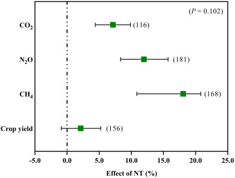

1. [Download : Download high-res image (104KB)](https://ars.els-cdn.com/content/image/1-s2.0-S0048969720358289-gr1_lrg.jpg)
2. [Download : Download full-size image](https://ars.els-cdn.com/content/image/1-s2.0-S0048969720358289-gr1.jpg)

Fig. 1. The overall effects of NT on GHGs emissions and crop yield. Parentheses numbers indicate the number of observations and error bars represent 95% confidence intervals. The relationship is considered significant if *P* < 0.05.

### 3.2. Soil texture

Effect sizes of soil texture on CO<sub>2</sub>, N<sub>2</sub>O, and CH<sub>4</sub> emissions as well as crop yield are shown in Fig. 2. According to our meta-analysis results, overall, soil texture did not show any significant effect on CO<sub>2</sub>, and N<sub>2</sub>O emissions as well as crop yield. In contrast, NT significantly enhanced CH<sub>4</sub> emissions as compared to CT (Fig. 2).

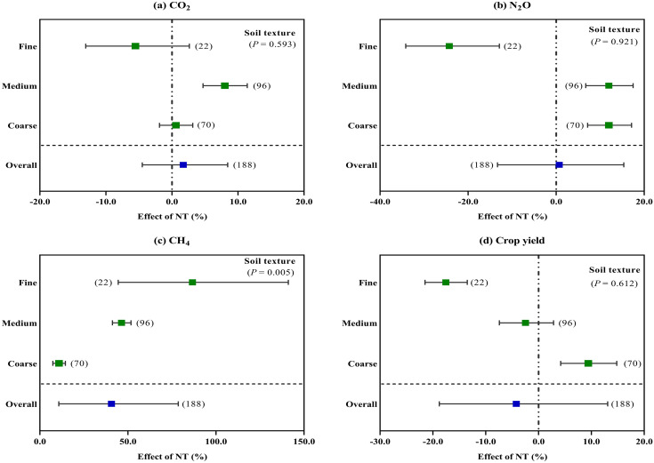

1. [Download : Download high-res image (402KB)](https://ars.els-cdn.com/content/image/1-s2.0-S0048969720358289-gr2_lrg.jpg)
2. [Download : Download full-size image](https://ars.els-cdn.com/content/image/1-s2.0-S0048969720358289-gr2.jpg)

Fig. 2. The effect soil textural classes on a) CO<sub>2</sub>, b) N<sub>2</sub>O, c) CH<sub>4</sub> emissions and d) crop yield following the application of NT. Parentheses numbers indicate the number of observations and error bars represent 95% confidence intervals. The relationship is considered significant if *P* < 0.05.

For CO<sub>2</sub> emissions, medium textured soils significantly increased CO<sub>2</sub> emissions by 8.0% (95% CI = 4.7%, 11.4%), whereas coarse ($lnRR¯$ = 0.6%, 95% CI = −1.8%, 3.1%) and fine ($lnRR¯$ = −5.5%, 95% CI = −13.0%, 2.6%) textured soils did not show any significant difference between NT and CT (Fig. 2(a)).

On the other hand, fine textured soils significantly reduced N<sub>2</sub>O emissions by 24.2% (95% CI = −34.1%, −12.8%) under NT as compared to CT (Fig. 2(b)). In contrast, N<sub>2</sub>O emissions significantly increased in coarse ($lnRR¯$ = 11.9%, 95% CI = 7.1%, 17.1%) and medium ($lnRR¯$ = 11.9%, 95% CI = 6.7%, 17.4%) textured soils under NT (versus CT) (Fig. 2(b)).

Moreover, on average, NT as compared to CT significantly enhanced CH<sub>4</sub> emissions by 40.6% (95% CI = 10.7%, 78.6%) (Fig. 2(c)). Maximum emission was observed in fine textured soils ($lnRR¯$ = 86.6%, 95% CI = 44.4%, 141.0%). While, NT also significantly increased CH<sub>4</sub> emission by 10.8% (95% CI = 7.3%, 14.4%) and 46.3% (95% CI = 41.1%, 51.7%) in coarse and medium textures soils, respectively (Fig. 2(c)).

Additionally, crop yield significantly increased in coarse textured soils by 9.4% (95% CI = 4.1%, 14.7%). In contrast, a significant reduction was observed in fine texture soils ($lnRR¯$ = −17.5%, 95% CI = −21.9%, −13.4%). However, no significant difference between CT and NT in medium textured soils (Fig. 2(d)).

### 3.3. Soil pH and C: N ratio

Fig. 3 shows the overall effect sizes of soil pH and C: N ratio on CO<sub>2</sub>, N<sub>2</sub>O and CH<sub>4</sub> emissions as well as crop yield from agricultural soils. On average, the NT significantly enhanced CO<sub>2</sub> emission as compared to CT under soil pH ($lnRR¯$ = 8.6%, 95% CI = 0.1%, 18.0%) and soil C: N ratio ($lnRR¯$ = 7.4%, 95% CI = 3.5%, 11.6%) (Fig. 3(a)). The NT as compared to CT significantly increased CO<sub>2</sub> emissions by 16.8% (95% CI = 12.6%, 21.4%) and 7.7% (95% CI = 3.4%, 12.1%) in alkaline and neural soils, respectively (Fig. 3(ai)). On the other hand, soil C: N ratios also significantly affected CO<sub>2</sub> emissions under NT (Fig. 3(aii)). Overall, soil C: N ratio enhanced CO<sub>2</sub> emissions by 7.4%. The maximum positive effect for NT (versus CT) was occurred with >10 C: N ratios ($lnRR¯$= 8.8%, 95% CI = 6.6%, 11.1%). However, no significant effect was observed in ≤10 C: N ratios (95% CI overlapped with zero) ($lnRR¯$ = 4.6%, 95% CI = −0.6%, 10.1%) (Fig. 3(aii)).

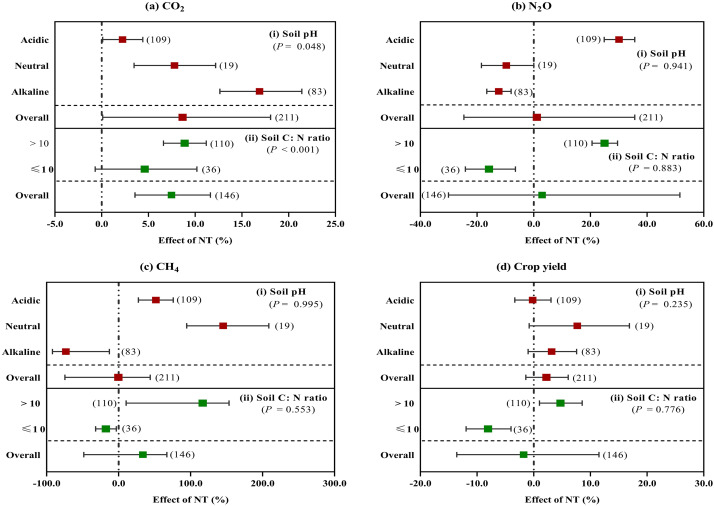

1. [Download : Download high-res image (551KB)](https://ars.els-cdn.com/content/image/1-s2.0-S0048969720358289-gr3_lrg.jpg)
2. [Download : Download full-size image](https://ars.els-cdn.com/content/image/1-s2.0-S0048969720358289-gr3.jpg)

Fig. 3. The impact of (i) soil pH and (ii) soil C: N ratio on a) CO<sub>2</sub>, b) N<sub>2</sub>O, c) CH<sub>4</sub> emissions and d) crop yield following the application of NT. Parentheses numbers indicate the number of observations and error bars represent 95% confidence intervals. The relationship is considered significant if *P* < 0.05.

For N<sub>2</sub>O emissions, overall, there was no significant difference for N<sub>2</sub>O emissions ($lnRR¯$ = 1.1%, 95% CI = −24.6%, 35.6%) between NT and CT in soil pH (Fig. 3(bi)). Similarly, overall, soil C: N ratios had no significant effect on N<sub>2</sub>O emissions (95% CI overlapped with zero) (Fig. 3(bii)). The maximum N<sub>2</sub>O emission was observed in acidic soils ($lnRR¯$ = 30.0%, 95% CI = 24.8%, 35.6%). In contrast, NT as compared to CT significantly mitigated N<sub>2</sub>O emissions under alkaline ($lnRR¯$ = −12.3%, 95% CI = −16.5%, −7.9%) and neutral ($lnRR¯$ = −9.6%, 95% CI = −18.4%, 0.1%) soils (Fig. 3(bi)). Similarly, overall, soil C: N ratios had no significant effect on N<sub>2</sub>O emissions (95% CI overlapped with zero) (Fig. 3(bii)). On the other hand, NT significantly reduced N<sub>2</sub>O emissions by 15.8% (95% CI = −24.1%, −6.4%) under ≤10 C: N ratios. In contrast, a significant increment in N<sub>2</sub>O emission ($lnRR¯$ = 24.9%, 95% CI = 20.5%, 29.5%) was observed with >10 C: N ratios under NT as compared to CT (Fig. 3(bii)).

The overall effect sizes of soil pH and C: N ratio for CH<sub>4</sub> emissions were ($lnRR¯$ = −0.3%, 95% CI = −74.6%, 43.9%) and ($lnRR¯$ = 33.6%, 95% CI = −48.3%, 26.9%), respectively (Fig. 3(c)) showing that both variables had not effect on CH<sub>4</sub> emission (because 95% CI overlapped with zero in both cases) under NT as compared to CT. Acidic and neutral soils significantly stimulated CH<sub>4</sub> emissions by 51.7% (95% CI = 47.5%, 55.8%), and 145.2% (95% CI = 94.6%, 208.6%), respectively. On the other hand, NT significantly reduced CH<sub>4</sub> emission by 73.2% (95% CI = −12.7%, −71.8%) in alkaline soils as compared with CT (Fig. 3(ci)). For C: N ratio, similar results were found as in N<sub>2</sub>O emission (Fig. 3(cii)).

For crop yield, overall effect sizes of soil pH ($lnRR¯$ = 2.2%, 95% CI = −1.3%, 6.0%) and C: N ratio ($lnRR¯$ = −1.7%, 95% CI = −13.5%, 11.5%) were not shown significant difference between NT and CT (Fig. 3(d)). No significant difference between NT and CT was observed in all soil pH classes (Fig. 3(di)). While a significant reduction ($lnRR¯$ = −8.0%, 95% CI = −11.9%, −0.9%) and increment ($lnRR¯$ = 4.7%, 95% CI = 1.0%, 8.5%) in crop yields were occurred with ≤10 and >10 C: N ratios, respectively (Fig. 3(dii)).

### 3.4. N application rate and crop duration

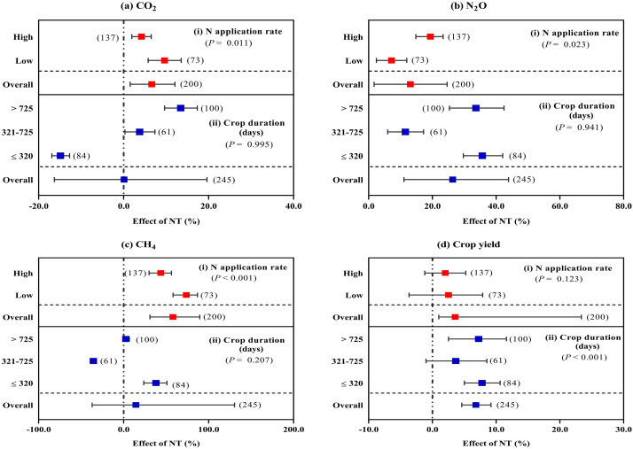

1. [Download : Download high-res image (556KB)](https://ars.els-cdn.com/content/image/1-s2.0-S0048969720358289-gr4_lrg.jpg)
2. [Download : Download full-size image](https://ars.els-cdn.com/content/image/1-s2.0-S0048969720358289-gr4.jpg)

Fig. 4. The effect of (i) N application rate and (ii) crop duration on a) CO<sub>2</sub>, b) N<sub>2</sub>O, c) CH<sub>4</sub> emissions and d) crop yield following the application of NT. Parentheses numbers indicate the number of observations and error bars represent 95% confidence intervals. The relationship is considered significant if *P* < 0.05.

On average, maximum CO<sub>2</sub> emission ($lnRR¯$ = 9.6%, 95% CI = 5.7%, 13.5%) was observed in low N application rate with NT CT (Fig. 4(ai)). In contrast, high N application rate significantly enhanced N<sub>2</sub>O emission by 19.3% (95% CI = 14.7%, 23.3%) (Fig. 4(bi)). On the other hand, low N application rate showed a strong positive effect ($lnRR¯$ = 73.6%, 95% CI = 68.2%, 76.8%) on CH<sub>4</sub> under NT as compared to CT (Fig. 4(ci)). However, there was no significant difference in crop yield in both low ($lnRR¯$ = 2.5%, 95% CI = −23.6%, 7.8%) as well as high ($lnRR¯$ = 2.0%, 95% CI = −1.1%, 5.2%) N application rate (because 95% CI overlapped with zero) (Fig. 4(di)).

### 3.5. Crop type

Crop species showed significant positive and negative effects on GHGs emissions and crop yield (Fig. 5). Overall, NT exhibited no significant effects on GHGs emissions as well as crop yield (all 95% Cl overlapped with zero) compared to CT (Fig. 5). On average, barley, rice and soybean significantly increased CO<sub>2</sub> emissions by 18.2% (95% CI = 15.4%, 21.1%), 8.5% (95% CI = 6.5%, 10.5%) and 27.6% (95% CI = 21.2%, 34.1%), respectively (Fig. 5(a)). In contrast, fallow soils significantly decreased CO<sub>2</sub> emissions by −36.9% % (95% CI = −40.7%, −32.9%). On the other hand, there were no changes in CO<sub>2</sub> emissions with maize, rapeseed and wheat crop species in NT as compared with CT (Fig. 5(a)).

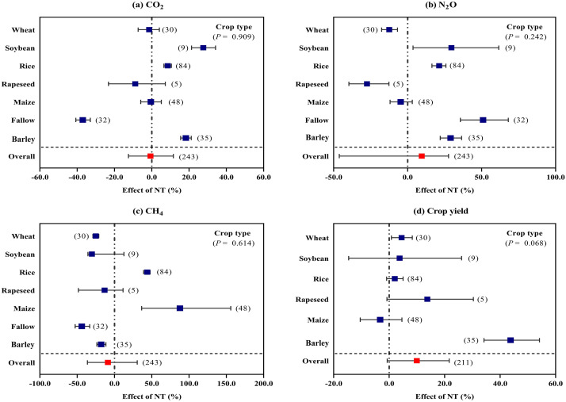

1. [Download : Download high-res image (486KB)](https://ars.els-cdn.com/content/image/1-s2.0-S0048969720358289-gr5_lrg.jpg)
2. [Download : Download full-size image](https://ars.els-cdn.com/content/image/1-s2.0-S0048969720358289-gr5.jpg)

Fig. 5. The Influence of crop types on a) CO<sub>2</sub>, b) N<sub>2</sub>O, c) CH<sub>4</sub> emissions and d) crop yield following the application of NT. Parentheses numbers indicate the number of observations and error bars represent 95% confidence intervals. The relationship is considered significant if *P* < 0.05.

After NT, N<sub>2</sub>O emissions significantly increased in barley, fallow, rice and soybean crops by 29.0%, 50.9%, 21.2% and 29.5%, respectably (Fig. 5(b)). Alternatively, N<sub>2</sub>O emissions significantly lower in rapeseed (−27.4%) and wheat (−12.3%) crops in NT (versus CT) (Fig. 5(b)). For CH<sub>4</sub> emission, maize ($lnRR¯$ = 87.7%, 95% CI = 36.3%, 155.9%) and rice ($lnRR¯$ = 43.9%, 95% CI = 39.0%, 47.6%) had strong positive effects after NT (Fig. 5(c)). Fallow soils, wheat and barley crops significantly reduced CH<sub>4</sub> emissions by −43.8%, −25.0% and −17.7%, respectively (Fig. 5(c)).

However, crop yields were not changed in NT as compared to CT in all crop species except barley and wheat (Fig. 5(d)). Maximum crop yields were observed in barley ($lnRR¯$ = 43.7%, 95% CI = 34.1%, 54.1%) and wheat ($lnRR¯$ = 4.4%, 95% CI = 0.8%, 8.3%) after NT as compared to CT (Fig. 5(d)).

### 3.6. Water management and climate zone

Water management practices and climate zones significantly affected GHGs emissions and crop yield. Overall, there were no significant differences between NT and CT in GHGs emissions and crop yield because overall effect sizes overlapped with zero in water management practices (Fig. 6(ai, bi, ci, di)).

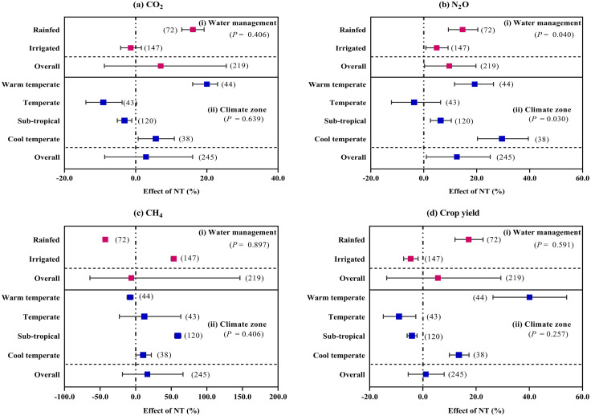

1. [Download : Download high-res image (610KB)](https://ars.els-cdn.com/content/image/1-s2.0-S0048969720358289-gr6_lrg.jpg)
2. [Download : Download full-size image](https://ars.els-cdn.com/content/image/1-s2.0-S0048969720358289-gr6.jpg)

Fig. 6. The impact of (i) water management and (ii) climate zones on a) CO<sub>2</sub>, b) N<sub>2</sub>O, c) CH<sub>4</sub> emissions and d) crop yield following the application of NT. Parentheses numbers indicate the number of observations and error bars represent 95% confidence intervals. The relationship is considered significant if *P* < 0.05.

On average, rainfed significantly increased CO<sub>2</sub> emissions by 16.0% (95% CI = 12.9%, 19.2%), however, no effect was observed in the irrigation system ($lnRR¯$ = −1.3%, 95% CI = −4.2%, 1.6%) (Fig. 6(ai)). Similarly, rainfed also had strong positive effects on N<sub>2</sub>O emission (14.6%) in NT as compared to CT (Fig. 6(bi)). However, NT in irrigated soils significantly increased CH<sub>4</sub> emission ($lnRR¯$ = 53.5%, 95% CI = 49.7%, 56.8%), whereas maximum reduction was observed in rainfed agricultural soils ($lnRR¯$ = −42.7%, 95% CI = −45.7%, −39.5%) as compared to CT (Fig. 6(ci)). On the other hand, crop yield significantly increased by 17.2% in the rainfed system, while significant reduction (−4.5%) was seen in irrigated soils after NT practice as compared with CT (Fig. 6(di)). Furthermore, warm and cool temperate climate zones significantly enhanced CO<sub>2</sub>, N<sub>2</sub>O emissions as well as crop yields (Fig. 6(aii, bii, dii)). Whereas, CH<sub>4</sub> emission significantly increased in sub-tropical climate zone ($lnRR¯$ = 59.0%, 95% CI = 54.8%, 63.5%) after NT practice (Fig. 6(cii)).

### 3.7. NT and overall GWP

Fig. 7 shows the responses GWP to NT as compared to CT. For GWP analysis, only those research studies were included who simultaneously reported CO<sub>2</sub>, N<sub>2</sub>O and CH<sub>4</sub> emissions. Overall, NT significantly reduced GWP by 7.5% (95% CI = −14.3%, −0.3%) as compared to CT (Fig. 7). Only 11 publications were used to measure the GWP (Table 1) and it might be the reason in the reduction of overall GWP.

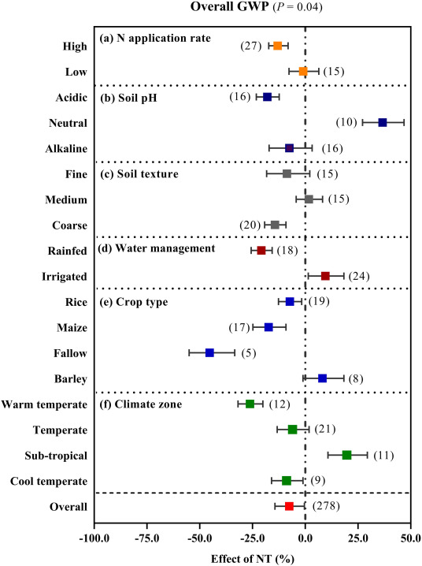

1. [Download : Download high-res image (512KB)](https://ars.els-cdn.com/content/image/1-s2.0-S0048969720358289-gr7_lrg.jpg)
2. [Download : Download full-size image](https://ars.els-cdn.com/content/image/1-s2.0-S0048969720358289-gr7.jpg)

Fig. 7. The effect of NT on the overall GWP of GHGs emissions. Parentheses numbers indicate the number of observations and error bars represent 95% confidence intervals. The relationship is considered significant if *P* < 0.05.

On average, the low N application rate did not exhibit any difference between NT and CT. In contrast, high N application rate significantly decreased GWP ($lnRR¯$ = −13.0%, 95% CI = −17.3%, −8.1%) (Fig. 7(a)). On the other hand, neutral soils significantly increased GWP ($lnRR¯$ = 36.6%, 95% CI = 27.1%, 46.8%), whereas acidic soils reduced GWP by 17.9% (Fig. 7(b)). Similarly, coarse textured soils also mitigated the GWP after NT as compared to CT ($lnRR¯$ = −14.3%, 95% CI = −19.2%, −9.1%) (Fig. 7(c)). However, rainfed and irrigated soils significantly decreased and increased GWP by 20.7% and 9.5%, respectively (Fig. 7(d)). Significant reductions in GWP after NT (versus CT) were observed in fallow (45.2%), rice (7.3%) and maize (17.3%) crops, whereas barley increased GWP by 8.1% (Fig. 7(e)). Furthermore, warm temperate climate zone significantly deceased GWP ($lnRR¯$ = −26.2%, 95% CI = −31.8%, −20.0%), while sub-tropical increased GWP by 19.7% (95% CI = 10.7%, 29.4%) after NT as compared to CT (Fig. 7(f)). Though a few studies reported all three GHGs emissions as well as crop yield after NT as compared with CT. These all results were probably affected through publication bias, and so should be understood cautiously.

## 4. Discussion

### 4.1. Effect of tillage on GHGs emissions and crop yield

Conservation tillage especially NT is becoming an effective and popular practice for decreased investment costs with improved soil fertility as well as C sequestration (Alvarez et al., 2014; Lal, 2004c). NT is considered as an effective technique to mitigate climate change. However, the effect of GHGs emissions and crop yield under NT practice is still controversial. Some research studies reported that NT significantly increased GHGs emissions (Oorts et al., 2007; Pandey et al., 2012; Yao et al., 2013b), whereas some studies showed that GHGs emissions significantly decreased under NT as compared to CT (Rutkowska et al., 2018; Tellez-Rio et al., 2015b).

According to our meta-analysis results, overall, NT significantly increased CO<sub>2</sub>, N<sub>2</sub>O and CH<sub>4</sub> emissions as compared to CT, whereas crop yield was similar between CT and NT (Fig. 1). Long-term application of NT practice significantly alters GHGs concentration through SOM stocks, soil physicochemical properties, and microbial composition and population. Huang et al. (2018) conducted a meta-analysis study and found that N<sub>2</sub>O emissions significantly increased without affecting crop yield in NT as compared to CT. Oorts et al. (2007) and Chatskikh and Olesen (2007) reported that CO<sub>2</sub> and N<sub>2</sub>O emissions significantly enhanced with NT as compared to CT. According to Ussiri et al. (2009), NT as compared to CT increased N<sub>2</sub>O emission but significantly decreased CH<sub>4</sub> emission in the winter cropping season. Li et al. (2011) studied and found that CH<sub>4</sub> emissions increased in early rice after NT practice as compared to CT.

Tillage practices have an important influence on CO<sub>2</sub> emissions. Usually, CT brings drastic changes to soil physical conditions that lead to increased CO<sub>2</sub> emissions (e.g. by 50%) due to stimulated SOM decomposition processes (Lal, 2006; Rutkowska et al., 2018). Furthermore, crop residues also significantly affect CO<sub>2</sub> emissions under NT. Crop residues provide ready available C and N substrates for microbial community and consequently enhances heterotrophic respiration due to increased soil microbial activities (Plaza-Bonilla et al., 2014b; Zhang et al., 2016; Z.S. Zhang et al., 2016; D. Zhang et al., 2016; G. Zhang et al., 2016), thus enhancing CO<sub>2</sub> emissions. Moreover, under long-term NT, decomposition of crop residues significantly increases because short-term field studies might not be significant source of CO<sub>2</sub> emissions associated with crop residues under NT practice (Oorts et al., 2007).

N<sub>2</sub>O emissions are significantly affected by nitrification and de-nitrification processes (Rodríguez, 2019; Shakoor et al., 2018). Some research studies have found that NT (versus CT) acts as a significant sink and/or source for N<sub>2</sub>O emissions (Almaraz et al., 2009b; Pandey et al., 2012) due to irrigation, high precipitation, N fertilization rate and placement. Moreover, crop residues might also have an important factor to stimulate the N<sub>2</sub>O emission under NT as compared to CT.

CH<sub>4</sub> emissions can be influenced by tillage practices (Canadell and Schulze, 2014; Smith et al., 2008; Zhao et al., 2016). Long-term NT practice increases soil bulk density, compaction and water-filled pore spaces (WFPS) (Bayer et al., 2012) which ultimately favors the anaerobic decomposition of SOM. On the other hand, long-term field experiments under NT practice also significantly increases water-stable macroaggregates with increases in SOM concentration and consequently increases methanotrophic activities resulting in CH<sub>4</sub> emissions (Álvaro-Fuentes et al., 2008a; Plaza-Bonilla et al., 2013).

In addition, fertilizer application rate and placement also play an important role in GHGs emissions under NT practice as compared to CT (Liu et al., 2020). For example, surface broadcast of N fertilizer under NT practice not only emits CH<sub>4</sub> but also significantly increases CO<sub>2</sub> and N<sub>2</sub>O emissions through temperature, moisture content and other environmental factors (Fan et al., 2020; Jian-She et al., 2011). Surface placement of chemical fertilizers provides sufficient substrate to the population of denitrifiers under NT (Liu et al., 2006). Nitrifiers and denitrifiers activities significantly decreased with depth under NT practice because deep N placement may reduce inorganic N substrates supply to these microbial community (Groffman, 1985; Venterea and Stanenas, 2008).

### 4.2. Effects of soil physicochemical properties on GHGs emissions and crop yield

#### 4.2.1. Soil texture

Emissions of GHGs and crop yield were significantly regulated by soil texture in NT practice. For CO<sub>2</sub>, the maximum emission was observed in medium textured soils in NT as compared to CT, whereas fine and coarse textured soils did not show any effect on CO<sub>2</sub> emission (Fig. 2(a)). Aslam et al. (2000) studied and observed that CO<sub>2</sub> emission significantly increased in silt loam soil with NT as compared to CT. Ahmad et al. (2009) and Pareja-Sánchez et al. (2019) also found that medium textured soil significantly increased CO<sub>2</sub> emission in NT (versus CT). Generally, medium textured soils contain more nutrients and soil moisture content. Under NT as compared to CT, the existence of crop residues (from the previous crop) on the soil surface increases water availability by reducing water loss through evaporation (Lampurlanés et al., 2016). The increased concentration in moisture contents observed under NT as compared to CT was accompanied by maximum CO<sub>2</sub> emissions indicating enzymatic activities stimulated by SOM contents (Pareja-Sánchez et al., 2019).

According to our meta-analysis results, coarse and medium textured soils significantly increased N<sub>2</sub>O emission with NT management practice (Fig. 2(b)). Ball et al. (2014), Sheehy et al. (2013) and Zhang et al. (2015) also came to the similar conclusions. Soil texture significantly controls the emissions of N<sub>2</sub>O through moderating the soil oxygen availability because soil texture has an important impact on the size as well as the distribution of soil pores (Corre et al., 1999). In coarse textured soils, the nitrification and denitrification processes significantly influenced N<sub>2</sub>O emissions (Zhou et al., 2014). Consumption of oxygen following SOM decomposition may enhance oxygen stress in microsites and significantly affect denitrification process and therefore N<sub>2</sub>O emissions might be less in fine textured soils as compared to coarse textured soils (Chen et al., 2013). Moreover, crop residues and N fertilizer application to agricultural soils provide a sufficient amount of C substrate that can stimulate the denitrification process and consequently enhance N<sub>2</sub>O emissions in NT as compared to CT.

Furthermore, coarse, medium, and fine textured soils significantly increased CH<sub>4</sub> emission by 10.8%, 46.3%, and 86.6% (Fig. 2(c)). Kim et al. (2016) conducted a long-term field experiment in fine silty soil and observed a much higher CH<sub>4</sub> emission in NT (36.0%) than the CT plot. Fine textured soils have maximum water holding capacity (USDA, 2008), which alternatively produce anaerobic conditions in the soil. Under anaerobic terrestrial environmental conditions, biological decomposition of the SOM by methanogens emits a significant amount of CH<sub>4</sub> from agricultural soils (Lu, 2011). However, soils with fine pores support the emission of CH<sub>4</sub> under anaerobic conditions (Ball, 2013; Dutaur and Verchot, 2007). On the other hand, the long-term application of NT can significantly alter the physical properties of soil, which may also change the microbial composition as well as the population (Elliott et al., 1988). Particularly, the bacterial communities which convert the biological polymers (for example hemicellulose and cellulose to carbohydrates) may supply more methanogenic substrates and ultimately affect the methanogenesis process and CH<sub>4</sub> emission under long-term NT practice as compared to CT (Demirel and Scherer, 2008).

Crop yield was also significantly affected by textural classes under NT. Our results revealed that coarse textured soil had a significant positive effect on crop yield in NT as compared to CT (Fig. 2(d)). Beyaert et al. (2002) studied and found that crop yield significantly increased in coarse textured soils in NT management practice as compared to CT. The increment in the crop yield in coarse textured soil can be attributed to the maximum availability of the water contents to plants in NT practice due to higher crop residues cover and precipitation.

#### 4.2.2. Soil pH and C: N ratio

Soil pH and C: N ratios significantly affect GHGs emissions and crop yield with the application of NT. In this meta-analysis, in NT, alkaline soils significantly enhanced CO<sub>2</sub> emission, whereas acidic and natural soils positively correlated with N<sub>2</sub>O and CH<sub>4</sub> emissions, respectively (Fig. 3(ai, bi, ci)). Huang et al. (2018) conducted a meta-analysis study and also found that acidic soils decreased CO<sub>2</sub> and CH<sub>4</sub> emissions, while significant stimulation was observed in N<sub>2</sub>O emission in NT as compared to CT. Mei et al. (2018) also performed a meta-analysis study and reported similar findings. Maximum N<sub>2</sub>O emissions from acidic soil under NT (versus CT) were also reported by other researchers (B. Liu et al., 2010; Samad et al., 2016).

Microbial activities significantly contribute to the global CO<sub>2</sub> emission and their activities are sensitive to soil pH. Increasing soil pH significantly improves basal respiration and consequently affect CO<sub>2</sub> emissions (Lundström et al., 2003). The activity of N<sub>2</sub>O reductase (N<sub>2</sub>OR) decreases significantly in acidic soils than alkaline soil as it is more sensitive to acidic soils which could inhibit N<sub>2</sub>O conversion to N<sub>2</sub>, leading to enhance in N<sub>2</sub>O (S. Liu et al., 2010; Liu et al., 2014). Other researchers studied and reported that nitrification as well as denitrification processes are influenced by soil pH and resulted in N<sub>2</sub>O emissions. Generally, autotrophic nitrifiers prefer neutral and/or slightly alkaline conditions for oxidizing NH<sub>4</sub><sup>+</sup> (ammonia) to NO<sub>3</sub><sup>−</sup> (nitrate), and therefore, the nitrification processes are also frequently lower in acidic soil conditions (Chen et al., 2013). Similarly, heterotrophic denitrifiers activities also slow in acidic soils as compared to alkaline soils. On the other hand, N<sub>2</sub>O fractions might be higher at low pH, mainly with an adequate NO<sub>3</sub><sup>−</sup> supply. This is normally attributed to the sensitivity of N<sub>2</sub>O reductase to proton activity (Bouwman, 2001).

Methanogenesis bacterial activities simulated under anaerobic soil conditions and ultimately increases CH<sub>4</sub> emission (J. Liu et al., 2015). According to Linn and Doran (1984) research study, the population of anaerobic microorganisms in the topsoil of NT soils was greater than CT soils might be due to higher crop residues on surface. Generally, the best soil pH for the methanogenesis process is considered closer to neutral. The growth and activity of these bacteria will be reduced at <5 and >8.5 soil's pH (Staley et al., 2011). Biological degradation of SOM is done with anaerobic bacteria and optimal activity was found with pH 7 (Horn et al., 2003). Wang et al. (1993) also found that the maximum CH<sub>4</sub> emissions were observed in the pH range of 6.9 to 7.1 (neutral soil pH) because methanogenic is acid sensitive. Thus, our meta-analysis study results were similar to previous research studies.

Higher soil C: N ratios (>10) had a strong positive effect on GHGs emissions (Fig. 3(aii, bii, cii)). Zhang et al. (2016), Z.S. Zhang et al. (2016), D. Zhang et al. (2016), G. Zhang et al. (2016) and Lin et al. (2015) found that maximum CO<sub>2</sub> and N<sub>2</sub>O emissions occurred in high soil C: N ratios (>10). Crop residues increase soil C: N ratio in NT soils as compared to CT, also enhance microbial activities, and alternatively increase GHGs emissions (Mosier et al., 2006a; Muñoz et al., 2019).

According to our meta-analysis results, there was no significant difference between NT and CT in crop yield at soil pH. While, higher soil C: N ratio increased crop yield (Fig. 3(di, dii)). There would be several environmental factors like climate, temperature, water content, textural class, and SOM content that can affect the crop yield and should be considered properly in future research studies.

### 4.3. N application rate and crop duration

GHGs emissions and crop yield significantly influenced by N application rate and duration of study. Generally, it is considered that N application rate is directly proportional to GHGs emissions and crop yield. According to our study, low rate of N application (≤120 kg N ha<sup>−1</sup>) significantly increased CO<sub>2</sub> and CH<sub>4</sub> emissions by 9.6% and 73.6%, whereas a high level of N application rate significantly enhanced N<sub>2</sub>O emissions in NT plots as compared to CT (Fig. 4(ai, bi, ci)). In contrast, N application rate did not show any significant difference between NT and CT on crop yield (Fig. (di)).

Mosier et al. (2006b) also found that plot with a low level of N fertilizer and/or control plot produced more CO<sub>2</sub> and CH<sub>4</sub> emissions under NT as compared to CT. Aronson and Helliker (2010) conducted a meta-analysis study and found that a low level of N application significantly increased CH<sub>4</sub> emissions. However, Huang et al. (2018), Plaza-Bonilla et al. (2017) and Abdalla et al. (2016) studied and found no significant difference between NT and CT on CO<sub>2</sub> emissions with N fertilizer application rate as well as placement. In our case, firstly, it might be possible that the plot with a low level of N application rate has more crop residues and moisture contents which favor the CO<sub>2</sub> emissions. Secondly, duration of the tillage operation particularly NT can also be an important factor to stimulate CO<sub>2</sub> emission. Concentration of soil organic carbon (SOC) significantly increased under NT during long-term (4 and 50 years) field experiments (Lemke et al., 2010; Morell et al., 2010) because application of N fertilizer stimulated biological activities and resulting more CO<sub>2</sub> emissions. Therefore, it is highly recommended that in future studies these factors should be reported properly.

Generally, it is expected that the application of NH<sub>4</sub><sup>+</sup> containing synthetic fertilizer will lead to reduced CH<sub>4</sub> oxidation (Bedard and Knowles, 1989; Sylvia et al., 2005). Nevertheless, this response is totally rate dependent; a low level of N application tends to increase CH<sub>4</sub> emission while a high rate of N application significantly reduces CH emission from agricultural soil (Aronson and Helliker, 2010).

Zhao et al. (2016) conducted a meta-analysis study and found that a high level of N application significantly increased N<sub>2</sub>O emission under NT as compared to CT. Shakoor et al. (2018) also conducted a field experiment and reported that N<sub>2</sub>O emission increased with a higher level of N application rate. High level of N application significantly stimulates the denitrification process and ultimately releases more N<sub>2</sub>O. Moreover, type and time of N fertilizer also influences the nitrification as well as denitrification processes. For example, anhydrous ammonia, which is commonly injected, shows maximum losses as compared to other fertilizers. Furthermore, soil physiochemical conditions are also expected to be favorable to increase denitrifying activities in NT as compared to CT (Venterea et al., 2005).

On the other hand, crop duration with NT management significantly affects GHGs emissions as well as crop yield. In this study, crops that are having >725 days had a strong positive effect on CO<sub>2</sub>, N<sub>2</sub>O emissions and crop yield (Fig. 4(aii, bii, dii)), whereas CH<sub>4</sub> emission was significantly affected with ≤320 days in NT as compared to CT (Fig. 4(cii)). Mei et al. (2018) and Huang et al. (2018) had also found similar findings. Long-term application of NT practice may decrease and/or resist the microbial activities (Alluvione et al., 2009). According to Oorts et al. (2007), the long-term application of NT significantly increased C stocks and then ultimately stimulated CO<sub>2</sub> emission. Duration of study with NT practice as compared to CT were also affected by soil physiochemical conditions, like soil compaction, water-filled pore spaces, aeration and soil structure which can significantly alter the microbial communities as well as activities to produce GHGs.

### 4.4. Crop type

The crop species also played an important role in the emissions of GHGs and crop yield (Huang et al., 2018). Barley and soybean crops significantly increased CO<sub>2</sub> emissions, while rice, soybean, barley and fallow soils had strong positive effects on N<sub>2</sub>O emissions in NT as compared to CT (Fig. 5(a, b)). Moreover, rice and maize crops significantly enhanced CH<sub>4</sub> emissions (Fig. 5(c)). On the other hand, NT did not show any effect on crop yield except barley (Fig. 5(d)). Behnke et al. (2018) conducted a long-term field experiment and observed that soybean produced more CO<sub>2</sub> emissions than maize under NT management compared with CT. Gan et al. (2012) studied and reported a barley significantly enhanced CO<sub>2</sub> emission. According to Zhang et al. (2016), Z.S. Zhang et al. (2016), D. Zhang et al. (2016), G. Zhang et al. (2016) and Hurisso et al. (2016) studies, the maximum N<sub>2</sub>O emission was observed in the fallow season. Pareja-Sánchez et al. (2019) and Wu et al. (2019) also studied and reported that maize and rice fields are a significant increase in CH<sub>4</sub> emissions in NT.

In NT management fields, microbial activities are the key factor for stimulating the GHGs emissions (Banger et al., 2012; Wang et al., 2019). The heterotrophic microbes significantly increase decomposition SOM (K Bore et al., 2017). The decomposition of SOM significantly enhance C mineralization and ultimately increases CO<sub>2</sub> emissions from croplands (Hossain et al., 2017). Higher N<sub>2</sub>O emission from the fallow seasons might be due to the increased mineralization process. The maximum N<sub>2</sub>O fluxes from rice, soybean, and barley crops may be associated with the higher N application rate, higher soil water contents (SWC), temperatures and crop residues, which increased nitrifier as well as denitrifier activities in NT as compared to CT (Hu et al., 2019). On the other hand, biological N fixation by leguminous crops, like soybean, alfalfa, and Cereals, also provides an important impact on N level in agricultural soils. For example, transformation of organic N in soybean nodules is mineralized into NH<sub>4</sub><sup>+</sup> that will be converted into N<sub>2</sub>O by nitrifier and denitrifier activities (Sánchez and Minamisawa, 2019). The CH<sub>4</sub> emissions from croplands depend on the availability of SOC content and anaerobic conditions (Tariq et al., 2017). In addition, soil temperature, bulk density and water contents also play a vital role in methanogens activity under NT management fields (Mitra et al., 2002) that significantly affected CH<sub>4</sub> emission.

Furthermore, the maximum yield was observed in barley crops under NT (Fig. 5(d)). A meta-analysis study reported that barley yield increased in NT practice (Huang et al., 2018). Another researcher studied in the Mediterranean climate and found that yield significantly increased in NT as compared to CT due to maximum WUE (water use efficiency) (Plaza-Bonilla et al., 2014a).

### 4.5. Water management and climate zone

According to our meta-analysis results, the rain-fed system significantly stimulated CO<sub>2</sub> and N<sub>2</sub>O emission, whereas irrigated lands produced more CH<sub>4</sub> emissions (Fig. 6(ai, bi, ci)). De Sanctis et al. (2012) studied and reported that long-term NT management practice significantly increased SOC in the rain-fed region and consequently enhanced CO<sub>2</sub> emission. Another researcher studied and found that NT management as compared to CT significantly increased SOC particularly in topsoil (0-20 cm) in the rain-fed system (Álvaro-Fuentes et al., 2008c). Plaza-Bonilla et al. (2014a) and Tellez-Rio et al. (2015a) found maximum N<sub>2</sub>O emission from the rain-fed Mediterranean region under NT as compared with CT. Previous research studies describe that emission of N<sub>2</sub>O from continuous flooded croplands was negligible (Fangueiro et al., 2017; Liu et al., 2010a; Zou et al., 2005). Greater N<sub>2</sub>O emission under NT as compared to CT may be due to fertilizer placement (topdressing) and crop residues. In addition, soil wetting and drying conditions also favored nitrification as well as denitrification processes. In rainfed agricultural system, wetting and drying cycles produced in soil by rainfall that provide ideal conditions for both nitrification and denitrification processes (Shi et al., 2013). Feng et al. (2018) conducted a meta-analysis study and found that continuous irrigation significantly affected CH<sub>4</sub> emissions in NT as compared to CT. Continuous flooding significantly affects the microbial activities in the terrestrial environment (Gebremichael et al., 2017) and increases anaerobic conditions. This process significantly affects the decomposition rate of SOM and ultimately alters the CH<sub>4</sub> emissions.

Warm temperature significantly increased CO<sub>2</sub> and N<sub>2</sub>O emissions by 20.2% and 19.2%, respectively, while sub-tropical environment had a strong positive effect on CH<sub>4</sub> emission (Fig. 6(aii, bii, cii)). Oorts et al. (2007) studied and reported that warm and dry climate significantly enhanced CO<sub>2</sub> emission under NT. Soil moisture and higher temperature stimulate the decomposition of crop residue and SOM that ultimately effect CO<sub>2</sub> emissions. Warm-temperate climate zone with high surface temperature may also increase nitrifiers activities, resulting in CO<sub>2</sub> emission (Feng et al., 2013). Under NT, maximum soil water contents were reported in the topsoil layer (0-5 cm) (Al-Kaisi and Yin, 2005; Alvarez et al., 2001). This shows that climatic conditions and zones partly control CO<sub>2</sub> emission flux in NT as compared with CT.

According to Mei et al. (2018) meta-analysis study, tropical and warm-temperature climate zones significantly increase N<sub>2</sub>O emission in NT. Van Kessel et al. (2013) also conducted a meta-analysis study and found that warm dry climate significantly enhanced N<sub>2</sub>O emission. Mostly, rainfall and temperature are the key factors in regulating N<sub>2</sub>O emissions across climate zones. Higher rainfall leads to increase soil moisture content and ultimately reduce the concentration of soil oxygen (O<sub>2</sub>), which significantly enhance nitrification as well as denitrification dynamics. In warm-temperate climate zone, decomposition rate of SOM and co-efficient of N turnover significantly higher, which can increase heterotrophic microbial activities and ultimately improve soil respiration (Zhou et al., 2011). Sub-tropical climate zone had strong positive effects on CH<sub>4</sub> emission through extreme precipitation events (Cheng-Fang et al., 2012; Li et al., 2013). Basically, most of the studies that are used in this meta-analysis were conducted in sub-tropical regions. Soil moisture level, temperature, precipitation and N fertilizer application rate might be considered as the key factors in regulating CH<sub>4</sub> emission in sub-tropical regions.

Responses of crop yield to water management and climate zone significantly affected in NT as compared with CT (Fig. 6(di, dii)). According to our results, rain-fed regions and warm temperate climate zones enhanced crop yield. Pittelkow et al. (2015) conducted a meta-analysis study and came to similar conclusions. In a long-term field experiment, it has been reported that wheat yield under NT as compared to CT in the rain-fed Mediterranean region increased (Amato et al., 2013). Another researcher also reported similar results (Toliver et al., 2012). According to Plaza-Bonilla et al. (2014a), better WUE is the key factor for getting maximum yield in rain-fed regions. In warm temperate climate zone, application of N fertilizers and soil water contents play an important role in crop growth and yield (Stuecker et al., 2018). According to Pittelkow et al. (2015) study, NT management practice performs better as compared to CT in warm and dry climates.

### 4.6. NT and overall GWP

GWP is a basic index to calculate the future influences of GHGs based on their lifetime and radiative forcing (IPCC, 2013). Overall, NT significantly decreased GWP by 7.5% (Fig. 7). GWP only calculated from those publications who simultaneously measured all three GHGs emission fluxes. According to our meta-analysis results, soil physicochemical properties, crop types, climate zones, N application rate and water management significantly affected GWP in NT as compared to CT. On average, all the variables significantly mitigated GHGs emissions. In contrast, neutral soil pH, irrigated lands, barley crop and sub-tropical climate zones had strong positive effects on GWP of GHGs emissions (Fig. 7). Huang et al. (2018) and Feng et al. (2018) conducted meta-analysis studies and found similar findings. Generally, it is considered that NT as compared to CT can increase soil C sequestration, reduce C mineralization rate and soil disturbance, which helps in GHGs mitigation (Sainju, 2016). Soil aggregates are significantly affected by RT and/or NT management practices that inhibit N mineralization process, consequently mitigate the N<sub>2</sub>O emission (Chen et al., 2013). Continuous irrigation may also weaken the efficiency of NT practice by enhancing soil water contents and anaerobic conditions, which increases methanotrophic activities (Feng et al., 2018). Non-legumes crop, such as barley increased GWP than legumes crop (lentil and pea) because non-legumes crop required high amount of N fertilizer to sustain crop production and high amount of N fertilizer significantly increases N<sub>2</sub>O emission (Sainju et al., 2014a, Sainju et al., 2014b).

Agriculture and its related land use contribute to C and N dynamics, affecting the flux of CO<sub>2</sub>, N<sub>2</sub>O, and CH<sub>4</sub>, which represent the GHGs principally linked to agricultural activities. Agricultural soils released a significant amount of GHGs emissions to the atmospheric environment, which estimated for one-fifth (approximately) of the annual increase in radiative forcing (Cole et al., 1997; He et al., 2017). According to the FAO (2014) emissions of GHGs from crops were approximately 5.3 Pg of CO<sub>2</sub>eq in 2011. Although agricultural management practices under NT significantly change the GWP of GHGs emissions (Guardia et al., 2016).

## 5. Limitations

In this meta-analysis study, numerous limitations should be considered in future research studies. Many meta-analysis studies have already been published but they did not found any significant difference between NT and CT (Abdalla et al., 2016; Feng et al., 2018; Huang et al., 2018; Mei et al., 2018). Our study reveals that differences in GHGs emissions and crop yield do exist between NT and CT management practices. Normally, NT management practice is adopted on sloping soils (Pittelkow et al., 2015). But, long-term implementation of NT management practice on field experiments can significantly contribute to GHGs mitigation. In our dataset, most of the studies have been conducted in China, North America and Europe. There remains a lack of experimental studies in other continents, like South America, South-East Asia, Africa and Australia. Thus, long-term field experimental research studies are needed to be conducted with NT management practice in these regions. This meta-analysis study only measured GHGs fluxes during the cropping and/or fallow seasons. In future research, non-cropping seasons particularly in regions with snow covers and freezing and thawing conditions must be included. Additionally, most of the studies that are comprised in this meta-analysis study did not report soil physiochemical properties, crop management practices and weather conditions. So, we urge that researchers should include proper timing of NT practice, complete soil physiochemical properties like soil pH, bulk density, soil texture, water filled pore spaces, air temperature, climate zone, timing and amount of rainfall, N fertilizer rate and timing, flux type and unit, number of observations and control treatment in their future research studies. This will greatly assist in future meta-analyses which can hopefully provide far greater insights into the range and variability of GHGs emissions than any individual study. Furthermore, it would also be very helpful to understand the difference between CT and NT management practice if the researcher could measure GHGs emissions fluxes during the whole year with specific time intervals, with and without cropping seasons. Last but not the least; researchers must measure all three GHGs fluxes under NT practice in a single study with the same treatments to calculate the GWP.

## CRediT authorship contribution statement

**Awais Shakoor:** Conceptualization, Methodology, Formal analysis, Data curation, Software, Writing - original draft, Writing - review & editing. **Muhammad Shahbaz:** Writing - review & editing. **Taimoor Hassan Farooq:** Software, Data curation. **Najam E. Sahar:** Writing - review & editing. **Sher Muhammad Shahzad:** Project administration, Writing - review & editing. **Muhammad Mohsin Altaf:** Data curation, Writing - review & editing. **Muhammad Ashraf:** Investigation, Writing - review & editing.

## Declaration of competing interest

The authors declare that they have no known competing financial interests or personal relationships that could have appeared to influence the work reported in this paper.

## Acknowledgments

Awais Shakoor would like to express his gratitude for the grant provided by the University of Lleida, Spain. The authors would like to appreciate the valuable comments from the editors and anonymous reviewers to improve the quality of this study.

## References

**Abdalla et al., 2016**

K. Abdalla, P. Chivenge, P. Ciais, V. Chaplot**No-tillage lessens soil CO2 emissions the most under arid and sandy soil conditions: results from a meta-analysis**

Biogeosciences, 13 (2016), pp. 3619-3633, 10.5194/bg-13-3619-2016

[CrossRef](https://doi.org/10.5194/bg-13-3619-2016)[View Record in Scopus](https://www.scopus.com/inward/record.url?eid=2-s2.0-84976303125&partnerID=10&rel=R3.0.0)Google Scholar

**Ahmad et al., 2009**

S. Ahmad, C. Li, G. Dai, M. Zhan, J. Wang, S. Pan, C. Cao**Greenhouse gas emission from direct seeding paddy field under different rice tillage systems in central China**

Soil Tillage Res., 106 (2009), pp. 54-61, 10.1016/j.still.2009.09.005

[Article](https://www.sciencedirect.com/science/article/pii/S0167198709001664)[Download PDF](https://www.sciencedirect.com/science/article/pii/S0167198709001664/pdfft?md5=054813b296dad90457ff0c02e6a70020&pid=1-s2.0-S0167198709001664-main.pdf)[View Record in Scopus](https://www.scopus.com/inward/record.url?eid=2-s2.0-71549138369&partnerID=10&rel=R3.0.0)Google Scholar

**Al-Kaisi and Yin, 2005**

M.M. Al-Kaisi, X. Yin**Tillage and crop residue effects on soil carbon and carbon dioxide emission in corn-soybean rotations**

J. Environ. Qual., 34 (2005), pp. 437-445, 10.2134/jeq2005.0437

[CrossRef](https://doi.org/10.2134/jeq2005.0437)[View Record in Scopus](https://www.scopus.com/inward/record.url?eid=2-s2.0-15744368358&partnerID=10&rel=R3.0.0)Google Scholar

**Alluvione et al., 2009**

F. Alluvione, A.D. Halvorson, S.J. Del Grosso**Nitrogen, tillage, and crop rotation effects on carbon dioxide and methane fluxes from irrigated cropping systems**

J. Environ. Qual., 38 (2009), pp. 2023-2033, 10.2134/jeq2008.0517

[CrossRef](https://doi.org/10.2134/jeq2008.0517)[View Record in Scopus](https://www.scopus.com/inward/record.url?eid=2-s2.0-69749111478&partnerID=10&rel=R3.0.0)Google Scholar

**Almaraz et al., 2009a**

J.J. Almaraz, F. Mabood, X. Zhou, C. Madramootoo, P. Rochette, B.-L. Ma, D.L. Smith**Carbon dioxide and nitrous oxide fluxes in corn grown under two tillage systems in Southwestern Quebec**

Soil Sci. Soc. Am. J., 73 (2009), pp. 113-119, 10.2136/sssaj2006.0371

[CrossRef](https://doi.org/10.2136/sssaj2006.0371)[View Record in Scopus](https://www.scopus.com/inward/record.url?eid=2-s2.0-60549085582&partnerID=10&rel=R3.0.0)Google Scholar

**Almaraz et al., 2009b**

J.J. Almaraz, X. Zhou, F. Mabood, C. Madramootoo, P. Rochette, B.L. Ma, D.L. Smith**Greenhouse gas fluxes associated with soybean production under two tillage systems in southwestern Quebec**

Soil Tillage Res., 104 (2009), pp. 134-139, 10.1016/j.still.2009.02.003

[Article](https://www.sciencedirect.com/science/article/pii/S0167198709000336)[Download PDF](https://www.sciencedirect.com/science/article/pii/S0167198709000336/pdfft?md5=91b305e5bdcff7e19554092d55a7ef0c&pid=1-s2.0-S0167198709000336-main.pdf)[View Record in Scopus](https://www.scopus.com/inward/record.url?eid=2-s2.0-67349154432&partnerID=10&rel=R3.0.0)Google Scholar

**Alvarez et al., 2001**

R. Alvarez, C.R. Alvarez, G. Lorenzo**Carbon dioxide fluxes following tillage from a mollisol in the Argentine Rolling Pampa**

Eur. J. Soil Biol., 37 (2001), pp. 161-166, 10.1016/S1164-5563(01)01085-8

[Article](https://www.sciencedirect.com/science/article/pii/S1164556301010858)[Download PDF](https://www.sciencedirect.com/science/article/pii/S1164556301010858/pdfft?md5=31e1e831a629d94737057516754f8d02&pid=1-s2.0-S1164556301010858-main.pdf)[View Record in Scopus](https://www.scopus.com/inward/record.url?eid=2-s2.0-0034823896&partnerID=10&rel=R3.0.0)Google Scholar

**Alvarez et al., 2014**

C. Alvarez, C.R. Alvarez, A. Costantini, M. Basanta**Carbon and nitrogen sequestration in soils under different management in the semi-arid Pampa (Argentina)**

Soil Tillage Res., 142 (2014), pp. 25-31, 10.1016/j.still.2014.04.005

[Article](https://www.sciencedirect.com/science/article/pii/S0167198714000804)[Download PDF](https://www.sciencedirect.com/science/article/pii/S0167198714000804/pdfft?md5=f3d183a69fb0d88730e23d20a2edce08&pid=1-s2.0-S0167198714000804-main.pdf)[View Record in Scopus](https://www.scopus.com/inward/record.url?eid=2-s2.0-84901330179&partnerID=10&rel=R3.0.0)[Google Scholar](https://scholar.google.com/scholar?q=Carbon%20and%20nitrogen%20sequestration%20in%20soils%20under%20different%20management%20in%20the%20semi-arid%20Pampa)

**Álvaro-Fuentes et al., 2008a**

J. Álvaro-Fuentes, J.L. Arrúe, R. Gracia, M.V. López**Tillage and cropping intensification effects on soil aggregation: temporal dynamics and controlling factors under semiarid conditions**

Geoderma, 145 (2008), pp. 390-396, 10.1016/j.geoderma.2008.04.005

[Article](https://www.sciencedirect.com/science/article/pii/S0016706108001031)[Download PDF](https://www.sciencedirect.com/science/article/pii/S0016706108001031/pdfft?md5=5ec0fd52624678ca10deee8285c73735&pid=1-s2.0-S0016706108001031-main.pdf)[View Record in Scopus](https://www.scopus.com/inward/record.url?eid=2-s2.0-45449092748&partnerID=10&rel=R3.0.0)Google Scholar

**Álvaro-Fuentes et al., 2008b**

J. Álvaro-Fuentes, M.V. López, J.L. Arrúe, C. Cantero-Martínez**Management effects on soil carbon dioxide fluxes under semiarid Mediterranean conditions**

Soil Sci. Soc. Am. J., 72 (2008), pp. 194-200, 10.2136/sssaj2006.0310

[CrossRef](https://doi.org/10.2136/sssaj2006.0310)[View Record in Scopus](https://www.scopus.com/inward/record.url?eid=2-s2.0-38349103075&partnerID=10&rel=R3.0.0)Google Scholar

**Álvaro-Fuentes et al., 2008c**

J. Álvaro-Fuentes, M.V. López, C. Cantero-Martinez, J.L. Arrúe**Tillage effects on soil organic carbon fractions in Mediterranean dryland agroecosystems**

Soil Sci. Soc. Am. J., 72 (2008), pp. 541-547, 10.2136/sssaj2007.0164

[CrossRef](https://doi.org/10.2136/sssaj2007.0164)[View Record in Scopus](https://www.scopus.com/inward/record.url?eid=2-s2.0-40849096308&partnerID=10&rel=R3.0.0)Google Scholar

**Amato et al., 2013**

G. Amato, P. Ruisi, A.S. Frenda, G. di Miceli, S. Saia, A. Plaia, D. Giambalvo**Long-term tillage and crop sequence effects on wheat grain yield and quality**

Agron. J., 105 (2013), pp. 1317-1327, 10.2134/agronj2013.0019

[CrossRef](https://doi.org/10.2134/agronj2013.0019)[View Record in Scopus](https://www.scopus.com/inward/record.url?eid=2-s2.0-84881002448&partnerID=10&rel=R3.0.0)Google Scholar

**Aronson and Helliker, 2010**

E.L. Aronson, B.R. Helliker**Methane flux in non-wetland soils in response to nitrogen addition: a meta-analysis**

Ecology, 91 (2010), pp. 3242-3251, 10.1890/09-2185.1

[CrossRef](https://doi.org/10.1890/09-2185.1)[View Record in Scopus](https://www.scopus.com/inward/record.url?eid=2-s2.0-78249272701&partnerID=10&rel=R3.0.0)Google Scholar

**Aslam et al., 2000**

T. Aslam, M.A. Choudhary, S. Saggar**Influence of land-use management on CO2 emissions from a silt loam soil in New Zealand**

Agric. Ecosyst. Environ., 77 (2000), pp. 257-262, 10.1016/S0167-8809(99)00102-4

[Article](https://www.sciencedirect.com/science/article/pii/S0167880999001024)[Download PDF](https://www.sciencedirect.com/science/article/pii/S0167880999001024/pdfft?md5=8050486ab7d61bd4690852a4f743232a&pid=1-s2.0-S0167880999001024-main.pdf)[View Record in Scopus](https://www.scopus.com/inward/record.url?eid=2-s2.0-0033987431&partnerID=10&rel=R3.0.0)Google Scholar

**Attard et al., 2011**

E. Attard, S. Recous, A. Chabbi, C. De Berranger, N. Guillaumaud, J. Labreuche, L. Philippot, B. Schmid, X. Le Roux**Soil environmental conditions rather than denitrifier abundance and diversity drive potential denitrification after changes in land uses**

Glob. Chang. Biol., 17 (2011), pp. 1975-1989, 10.1111/j.1365-2486.2010.02340.x

[CrossRef](https://doi.org/10.1111/j.1365-2486.2010.02340.x)[View Record in Scopus](https://www.scopus.com/inward/record.url?eid=2-s2.0-79953289916&partnerID=10&rel=R3.0.0)Google Scholar

**Baggs et al., 2003**

E.M. Baggs, M. Stevenson, M. Pihlatie, A. Regar, H. Cook, G. Cadisch**Nitrous oxide emissions following application of residues and fertiliser under zero and conventional tillage**

Plant Soil, 254 (2003), pp. 361-370, 10.1023/A:1025593121839

[View Record in Scopus](https://www.scopus.com/inward/record.url?eid=2-s2.0-0141569129&partnerID=10&rel=R3.0.0)Google Scholar

**Ball, 2013**

B.C. Ball**Soil structure and greenhouse gas emissions: a synthesis of 20 years of experimentation**

Eur. J. Soil Sci., 64 (2013), pp. 357-373, 10.1111/ejss.12013

[CrossRef](https://doi.org/10.1111/ejss.12013)[View Record in Scopus](https://www.scopus.com/inward/record.url?eid=2-s2.0-84879410888&partnerID=10&rel=R3.0.0)[Google Scholar](https://scholar.google.com/scholar_lookup?title=Soil%20structure%20and%20greenhouse%20gas%20emissions%3A%20a%20synthesis%20of%2020%20years%20of%20experimentation&publication_year=2013&author=B.C.%20Ball)

**Ball et al., 1999**

B.C. Ball, A. Scott, J.P. Parker**Adsorption kinetics of CO2, O2, N2, and CH4 in cation-exchanged clinoptilolite**

Soil Tillage Res., 53 (1999), pp. 1313-1319

[View Record in Scopus](https://www.scopus.com/inward/record.url?eid=2-s2.0-85091260577&partnerID=10&rel=R3.0.0)Google Scholar

**Ball et al., 2014**

B.C. Ball, B.S. Griffiths, C.F.E. Topp, R. Wheatley, R.L. Walker, R.M. Rees, C.A. Watson, H. Gordon, P.D. Hallett, B.M. McKenzie, I.M. Nevison**Seasonal nitrous oxide emissions from field soils under reduced tillage, compost application or organic farming**

Agric. Ecosyst. Environ., 189 (2014), pp. 171-180, 10.1016/j.agee.2014.03.038

**Banger et al., 2012**

K. Banger, H. Tian, C. Lu**Do nitrogen fertilizers stimulate or inhibit methane emissions from rice fields?**

Glob. Chang. Biol., 18 (2012), pp. 3259-3267, 10.1111/j.1365-2486.2012.02762.x

**Bayer et al., 2012**

C. Bayer, J. Gomes, F.C.B. Vieira, J.A. Zanatta, M. de Cássia Piccolo, J. Dieckow**Methane emission from soil under long-term no-till cropping systems**

Soil Tillage Res., 124 (2012), pp. 1-7, 10.1016/j.still.2012.03.006

**Bayer et al., 2015**

C. Bayer, T. Zschornack, G.M. Pedroso, C.M. da Rosa, E.S. Camargo, M. Boeni, E. Marcolin, C.E.S. dos Reis, D.C. dos Santos**A seven-year study on the effects of fall soil tillage on yield-scaled greenhouse gas emission from flood irrigated rice in a humid subtropical climate**

Soil Tillage Res., 145 (2015), pp. 118-125, 10.1016/j.still.2014.09.001

**Bedard and Knowles, 1989**

C. Bedard, R. Knowles**CO oxidation by methanotrophs and nitrifiers**

Microbiology, 53 (1989), pp. 68-84

**Behnke et al., 2018**

G.D. Behnke, S.M. Zuber, C.M. Pittelkow, E.D. Nafziger, M.B. Villamil**Long-term crop rotation and tillage effects on soil greenhouse gas emissions and crop production in Illinois, USA**

Agric. Ecosyst. Environ., 261 (2018), pp. 62-70, 10.1016/j.agee.2018.03.007

**Beyaert et al., 2002**

R.P. Beyaert, J.W. Schott, P.H. White**Tillage effects on corn production in a coarse-textured soil in Southern Ontario**

Agron. J. (2002), pp. 767-774

**Bouwman, 2001**

A.F. Bouwman**Factors regulating nitrous oxide and nitric oxide emission. Glob. Estim. Gaseous Emiss. NH3, NO N2O From Agric. Land. Rome, Italy FAO IFA**

(2001), p. 16

**Canadell and Schulze, 2014**

J.G. Canadell, E.D. Schulze**Global potential of biospheric carbon management for climate mitigation**

Nat. Commun., 5 (2014), 10.1038/ncomms6282

**Chatskikh and Olesen, 2007**

D. Chatskikh, J.E. Olesen**Soil tillage enhanced CO2 and N2O emissions from loamy sand soil under spring barley**

Soil Tillage Res., 97 (2007), pp. 5-18, 10.1016/j.still.2007.08.004

**Chatskikh et al., 2008**

D. Chatskikh, J.E. Olesen, E.M. Hansen, L. Elsgaard, B.M. Petersen**Effects of reduced tillage on net greenhouse gas fluxes from loamy sand soil under winter crops in Denmark**

Agric. Ecosyst. Environ., 128 (2008), pp. 117-126, 10.1016/j.agee.2008.05.010

**Chen et al., 2013**

H. Chen, X. Li, F. Hu, W. Shi**Soil nitrous oxide emissions following crop residue addition: a meta-analysis**

Glob. Chang. Biol., 19 (2013), pp. 2956-2964, 10.1111/gcb.12274

**Cheng-Fang et al., 2012**

L. Cheng-Fang, Z. Dan-Na, K. Zhi-Kui, Z. Zhi-Sheng, W. Jin-Ping, C. Ming-Li, C. Cou-Gui**Effects of tillage and nitrogen fertilizers on CH4 and CO2 emissions and soil organic carbon in paddy fields of central China**

PLoS One, 7 (2012), pp. 1-9, 10.1371/journal.pone.0034642

**Choudhary et al., 2002**

M.A. Choudhary, A. Akramkhanov, S. Saggar**Nitrous oxide emissions from a New Zealand cropped soil: tillage effects, spatial and seasonal variability**

Agric. Ecosyst. Environ., 93 (2002), pp. 33-43

**Cole et al., 1997**

C.V. Cole, J. Duxbury, J. Freney, O. Heinemeyer, K. Minami, A. Mosier, K. Paustian, N. Rosenberg, N. Sampson, D. Sauerbeck, Q. Zhao**Global estimates of potential mitigation of greenhouse gas emissions by agriculture**

Nutr. Cycl. Agroecosystems, 49 (1997), pp. 221-228, 10.1023/A:1009731711346

**Corre et al., 1999**

M.D. Corre, D.J. Pennock, C. Van Kessel, D.K. Elliott**Estimation of annual nitrous oxide emissions from a transitional grassland-forest region in Saskatchewan, Canada**

Biogeochemistry, 44 (1999), pp. 29-49, 10.1023/A:1006025907180

**Datta et al., 2013**

A. Datta, P. Smith, R. Lal**Effects of long-term tillage and drainage treatments on greenhouse gas fluxes from a corn field during the fallow period**

Agric. Ecosyst. Environ., 171 (2013), pp. 112-123, 10.1016/j.agee.2013.03.014

**De Sanctis et al., 2012**

G. De Sanctis, P.P. Roggero, G. Seddaiu, R. Orsini, C.H. Porter, J.W. Jones**Long-term no tillage increased soil organic carbon content of rain-fed cereal systems in a Mediterranean area**

Eur. J. Agron., 40 (2012), pp. 18-27, 10.1016/j.eja.2012.02.002

**Demirel and Scherer, 2008**

B. Demirel, P. Scherer**The roles of acetotrophic and hydrogenotrophic methanogens during anaerobic conversion of biomass to methane: a review**

Rev. Environ. Sci. Biotechnol., 7 (2008), pp. 173-190, 10.1007/s11157-008-9131-1

**Derpsch et al., 2010**

R. Derpsch, T. Friedrich, A. Kassam, L. Hongwen**Current status of adoption of no-till farming in the world and some of its main benefits**

Int. J. Agric. Biol. Eng, 3 (2010), pp. 1-25, 10.3965/j.issn.1934-6344.2010.01.001-025

**Drury et al., 2006**

C.F. Drury, W.D. Reynolds, C.S. Tan, T.W. Welacky, W. Calder, N.B. McLaughlin**Emissions of nitrous oxide and carbon dioxide**

Soil Sci. Soc. Am. J., 70 (2006), pp. 570-581, 10.2136/sssaj2005.0042

**Dutaur and Verchot, 2007**

L. Dutaur, L.V. Verchot**A global inventory of the soil CH4 sink**

Glob. Biogeochem. Cycles, 21 (2007), pp. 1-9, 10.1029/2006GB002734

**Elliott et al., 1988**

E.T. Elliott, H.W. Hunt, D.E. Walter**Detrital foodweb interactions in North American grassland ecosystems**

Agric. Ecosyst. Environ., 24 (1988), pp. 41-56, 10.1016/0167-8809(88)90055-2

**Fan et al., 2020**

D.J. Fan, T.Q. Liu, F. Sheng, S.H. Li, C.G. Cao, C.F. Li**Nitrogen deep placement mitigates methane emissions by regulating methanogens and methanotrophs in no-tillage paddy fields**

Biol. Fertil. Soils (2020), 10.1007/s00374-020-01447-y

**Fangueiro et al., 2017**

D. Fangueiro, D. Becerra, Á. Albarrán, D. Peña, J. Sanchez-Llerena, J.M. Rato-Nunes, A. López-Piñeiro**Effect of tillage and water management on GHG emissions from Mediterranean rice growing ecosystems**

Atmos. Environ., 150 (2017), pp. 303-312, 10.1016/j.atmosenv.2016.11.020

**FAO, 2014**

FAO**Agriculture, Forestry and Other Land Use Emissions by Sources and Removals by Sinks**

(2014)

**Feng et al., 2013**

J. Feng, C. Chen, Y. Zhang, Z. Song, A. Deng, C. Zheng, W. Zhang**Impacts of cropping practices on yield-scaled greenhouse gas emissions from rice fields in China: a meta-analysis**

Agric. Ecosyst. Environ., 164 (2013), pp. 220-228, 10.1016/j.agee.2012.10.009

**Feng et al., 2018**

J. Feng, F. Li, X. Zhou, C. Xu, L. Ji, Z. Chen, F. Fang**Impact of agronomy practices on the effects of reduced tillage systems on CH4 and N2O emissions from agricultural fields: a global meta-analysis**

PLoS One, 13 (2018), pp. 1-17, 10.1371/journal.pone.0196703

**Fiorini et al., 2020**

A. Fiorini, S.C. Maris, D. Abalos, S. Amaducci, V. Tabaglio**Combining no-till with rye (Secale cereale L.) cover crop mitigates nitrous oxide emissions without decreasing yield**

Soil Tillage Res., 196 (2020), Article 104442, 10.1016/j.still.2019.104442

**Freeman et al., 1986**

P.R. Freeman, L.V. Hedges, I. Olkin**Statistical methods for meta-analysis**

Biometrics, 42 (1986), p. 454, 10.2307/2531069

**Gan et al., 2012**

Y. Gan, C. Liang, W. May, S.S. Malhi, J. Niu, X. Wang**Carbon footprint of spring barley in relation to preceding oilseeds and N fertilization**

Int. J. Life Cycle Assess., 17 (2012), pp. 635-645, 10.1007/s11367-012-0383-1

**Gebremichael et al., 2017**

A.W. Gebremichael, B. Osborne, P. Orr**Flooding-related increases in CO2 and N2O emissions from a temperate coastal grassland ecosystem**

Biogeosciences, 14 (2017), pp. 2611-2626, 10.5194/bg-14-2611-2017

**Grandy et al., 2006**

A.S. Grandy, T.D. Loecke, S. Parr, G.P. Robertson**Long-term trends in nitrous oxide emissions, soil nitrogen, and crop yields of till and no-till cropping systems**

J. Environ. Qual., 35 (2006), pp. 1487-1495, 10.2134/jeq2005.0166

**Groffman, 1985**

P.M. Groffman**Nitrification and denitrification in conventional and no-tillage soils**

Soil Sci. Soc. Am. J., 49 (1985), pp. 329-334, 10.2136/sssaj1985.03615995004900020011x

**Guardia et al., 2016**

G. Guardia, A. Tellez-Rio, S. García-Marco, D. Martin-Lammerding, J.L. Tenorio, M.Á. Ibáñez, A. Vallejo**Effect of tillage and crop (cereal versus legume) on greenhouse gas emissions and global warming potential in a non-irrigated Mediterranean field**

Agric. Ecosyst. Environ., 221 (2016), pp. 187-197, 10.1016/j.agee.2016.01.047

**Gupta et al., 2016**

D.K. Gupta, A. Bhatia, A. Kumar, T.K. Das, N. Jain, R. Tomer, S.K. Malyan, R.K. Fagodiya, R. Dubey, H. Pathak**Mitigation of greenhouse gas emission from rice-wheat system of the Indo-Gangetic plains: through tillage, irrigation and fertilizer management**

Agric. Ecosyst. Environ., 230 (2016), pp. 1-9, 10.1016/j.agee.2016.05.023

**Hao et al., 2016**

Q. Hao, C. Jiang, X. Chai, Z. Huang, Z. Fan, D. Xie, X. He**Drainage, no-tillage and crop rotation decreases annual cumulative emissions of methane and nitrous oxide from a rice field in Southwest China**

Agric. Ecosyst. Environ., 233 (2016), pp. 270-281, 10.1016/j.agee.2016.09.026

**Havlin et al., 2013**

J.L. Havlin, J.D. Beaton, S.L. Tisdale, W.R. Nelson, W.L. Nelson**Soil Fertility and Fertilizers, an Introduction to Nutrient Management Title Soil Fertility and Fertilizers**

vol. 50 (2013)

**He et al., 2011**

J. He, H. Li, R.G. Rasaily, Q. Wang, G. Cai, Y. Su, X. Qiao, L. Liu**Soil properties and crop yields after 11 years of no tillage farming in wheat-maize cropping system in North China Plain**

Soil Tillage Res., 113 (2011), pp. 48-54, 10.1016/j.still.2011.01.005

**He et al., 2017**

Y. He, X. Zhou, L. Jiang, M. Li, Z. Du, G. Zhou, J. Shao, X. Wang, Z. Xu, S. Hosseini Bai, H. Wallace, C. Xu**Effects of biochar application on soil greenhouse gas fluxes: a meta-analysis**

GCB Bioenergy, 9 (2017), pp. 743-755, 10.1111/gcbb.12376

**Hedges et al., 1999**

L.V. Hedges, J. Gurevitch, P.S. Curtis**The meta-analysis of response ratios in experimental ecology**

Ecology, 80 (1999), pp. 1150-1156, 10.1890/0012-9658(1999)080[1150:TMAORR]2.0.CO;2

**Horn et al., 2003**

M.A. Horn, C. Matthies, K. Küsel, A. Schramm, H.L. Drake**Hydrogenotrophic methanogenesis by moderately acid-tolerant methanogens of a methane-emitting acidic peat**

Appl. Environ. Microbiol., 69 (2003), pp. 74-83, 10.1128/AEM.69.1.74-83.2003

**Hossain et al., 2017**

M.B. Hossain, M.M. Rahman, J.C. Biswas, M.M.U. Miah, S. Akhter, M. Maniruzzaman, A.K. Choudhury, F. Ahmed, M.H.K. Shiragi, N. Kalra**Carbon mineralization and carbon dioxide emission from organic matter added soil under different temperature regimes**

Int. J. Recycl. Org. Waste Agric., 6 (2017), pp. 311-319, 10.1007/s40093-017-0179-1

**Hu et al., 2019**

N. Hu, Q. Chen, L. Zhu**The responses of soil N2O emissions to residue returning systems: a meta-analysis**

Sustain, 11 (2019), pp. 1-17, 10.3390/su11030748

**Huang et al., 2018**

Y. Huang, W. Ren, L. Wang, D. Hui, J.H. Grove, X. Yang, B. Tao, B. Goff**Greenhouse gas emissions and crop yield in no-tillage systems: a meta-analysis**

Agric. Ecosyst. Environ., 268 (2018), pp. 144-153, 10.1016/j.agee.2018.09.002

**Hurisso et al., 2016**

T.T. Hurisso, U. Norton, J.B. Norton, J. Odhiambo, S.J. Del Grosso, G.W. Hergert, D.J. Lyon**Dryland soil greenhouse gases and yield-scaled emissions in no-till and organic winter wheat-fallow systems**

Soil Sci. Soc. Am. J., 80 (2016), pp. 178-192, 10.2136/sssaj2015.08.0295

**IPCC, 2013**

IPCC**Climate change 2013: the physical science basis**

Clim. Chang., 2013 (2013), p. 1535, 10.1017/CBO9781107415324

**IPCC, 2014**

IPCC**Climate change 2014: synthesis report. Contribution of working groups I, II and III to the fifth assessment report of the intergovernmental panel on climate change**

J. Cryst. Growth (2014), 10.1016/S0022-0248(00)00575-3

**Jian-She et al., 2011**

Z. Jian-She, Z. Fu-Ping, Y. Jin-Hua, W. Jin-Ping, C. Ming-Li, C.F. Li, C.G. Cao**Emissions of N2O and NH3, and nitrogen leaching from direct seeded rice under different tillage practices in central China**

Agric. Ecosyst. Environ., 140 (2011), pp. 164-173, 10.1016/j.agee.2010.11.023

**Jobbagy and Jackson, 2000**

E.G. Jobbagy, R.B. Jackson**The vertical distribution of soil organic carbon and its relation to climate and vegetation**

Ecol. Appl., 10 (2000), p. 423, 10.2307/2641104

**Joshua et al., 2018**

H. Joshua, R.B. Kristofor, R. Casey, E.G. Edward, A.S. Nathan**Methane production as affected by tillage practice and NBPT rate from a silt-loam soil in Arkansas**

J. Rice Res. Dev., 1 (2018), pp. 49-58, 10.36959/973/419

**K Bore et al., 2017**

E. K Bore, C. Apostel, S. Halicki, Y. Kuzyakov, M.A. Dippold**Soil microorganisms can overcome respiration inhibition by coupling intra- and extracellular metabolism: 13C metabolic tracing reveals the mechanisms**

ISME J (2017), pp. 1-11, 10.1038/ismej.2017.3

**Kim et al., 2016**

S.Y. Kim, J. Gutierrez, P.J. Kim**Unexpected stimulation of CH4 emissions under continuous no-tillage system in mono-rice paddy soils during cultivation**

Geoderma, 267 (2016), pp. 34-40, 10.1016/j.geoderma.2015.12.021

**Kong et al., 2009**

A.Y.Y. Kong, S.J. Fonte, C. Van Kessel, J. Six**Transitioning from standard to minimum tillage: trade-offs between soil organic matter stabilization, nitrous oxide emissions, and N availability in irrigated cropping systems**

Soil & Tillage Research, 104 (2009), pp. 256-262, 10.1016/j.still.2009.03.004

**Krauss et al., 2017**

M. Krauss, R. Ruser, T. Müller, S. Hansen, P. Mäder, A. Gattinger**Impact of reduced tillage on greenhouse gas emissions and soil carbon stocks in an organic grass-clover ley - winter wheat cropping sequence**

Agric. Ecosyst. Environ., 239 (2017), pp. 324-333, 10.1016/j.agee.2017.01.029

**Lal, 2003**

R. Lal**Global potential of soil carbon sequestration to mitigate the greenhouse effect**

CRC. Crit. Rev. Plant Sci., 22 (2003), pp. 151-184, 10.1080/713610854

**Lal, 2004a**

R. Lal**Soil carbon sequestration to mitigate climate change**

Geoderma, 123 (2004), pp. 1-22, 10.1016/j.geoderma.2004.01.032

**Lal, 2004b**

R. Lal**Soil carbon sequestration impacts on global climate change and food security**

Science (80-.), 304 (2004), pp. 1623-1627

**Lal, 2004c**

R. Lal**Carbon emission from farm operations**

Environ. Int., 30 (2004), pp. 981-990, 10.1016/j.envint.2004.03.005

**Lal, 2006**

R. Lal**Enhancing crop yields in the developing countries through restoration of the soil organic carbon pool in agricultural lands**

L. Degrad. Dev., 17 (2006), pp. 197-209, 10.1002/ldr.696

**Lal, 2008**

R. Lal**Sequestration of atmospheric CO2 in global carbon pools**

Energy Environ. Sci., 1 (2008), pp. 86-100, 10.1039/b809492f

**Lal, 2015**

R. Lal**Sequestering carbon and increasing productivity by conservation agriculture**

J. Soil Water Conserv., 70 (2015), pp. 55A-62A, 10.2489/jswc.70.3.55A

**Lal et al., 2007**

R. Lal, R.F. Follett, B.A. Stewart, J.M. Kimble**Soil carbon sequestration to mitigate climate change and advance food security**

Soil Sci., 172 (2007), pp. 943-956, 10.1097/ss.0b013e31815cc498

**Lampurlanés et al., 2016**

J. Lampurlanés, D. Plaza-Bonilla, J. Álvaro-Fuentes, C. Cantero-Martínez**Long-term analysis of soil water conservation and crop yield under different tillage systems in Mediterranean rainfed conditions**

F. Crop. Res., 189 (2016), pp. 59-67, 10.1016/j.fcr.2016.02.010

**Lemke et al., 2010**

R.L. Lemke, A.J. VandenBygaart, C.A. Campbell, G.P. Lafond, B. Grant**Crop residue removal and fertilizer N: effects on soil organic carbon in a long-term crop rotation experiment on a Udic Boroll**

Agric. Ecosyst. Environ., 135 (2010), pp. 42-51, 10.1016/j.agee.2009.08.010

**Li et al., 2010**

C.F. Li, Z.K. Kou, J.H. Yang, M.L. Cai, J.P. Wang, C.G. Cao**Soil CO2 fluxes from direct seeding rice fields under two tillage practices in central China**

Atmos. Environ., 44 (2010), pp. 2696-2704, 10.1016/j.atmosenv.2010.04.045

**Li et al., 2011**

D. Li, M. Liu, Y. Cheng, D. Wang, J. Qin, J. Jiao, H. Li, F. Hu**Methane emissions from double-rice cropping system under conventional and no tillage in southeast China**

Soil Tillage Res., 113 (2011), pp. 77-81, 10.1016/j.still.2011.02.006

**Li et al., 2013**

C. Li, Z. Zhang, L. Guo, M. Cai, C. Cao**Emissions of CH4 and CO2 from double rice cropping systems under varying tillage and seeding methods**

Atmos. Environ., 80 (2013), pp. 438-444, 10.1016/j.atmosenv.2013.08.027

**Lin et al., 2015**

X.W. Lin, Z.B. Xie, J.Y. Zheng, Q. Liu, Q.C. Bei, J.G. Zhu**Effects of biochar application on greenhouse gas emissions, carbon sequestration and crop growth in coastal saline soil**

Eur. J. Soil Sci., 66 (2015), pp. 329-338, 10.1111/ejss.12225

**Linn and Doran, 1984**

D.M. Linn, J.W. Doran**Aerobic and anaerobic microbial populations in no-till and plowed soils**

Soil Sci. Soc. Am. J., 48 (1984), pp. 794-799, 10.2136/sssaj1984.03615995004800040019x

**Liu et al., 2006**

X.J. Liu, A.R. Mosier, A.D. Halvorson, F.S. Zhang**The impact of nitrogen placement and tillage on NO, N2O, CH 4 and CO2 fluxes from a clay loam soil**

Plant Soil, 280 (2006), pp. 177-188, 10.1007/s11104-005-2950-8

**Liu et al., 2010a**

B. Liu, P.T. Mørkved, Å. Frostegård, L.R. Bakken**Denitrification gene pools, transcription and kinetics of NO, N2O and N2 production as affected by soil pH**

FEMS Microbiol. Ecol., 72 (2010), pp. 407-417, 10.1111/j.1574-6941.2010.00856.x

**Liu et al., 2010b**

S. Liu, Y. Qin, J. Zou, Q. Liu**Effects of water regime during rice-growing season on annual direct N2O emission in a paddy rice-winter wheat rotation system in southeast China**

Sci. Total Environ., 408 (2010), pp. 906-913, 10.1016/j.scitotenv.2009.11.002

**Liu et al., 2014**

B. Liu, Å. Frostegård, L.R. Bakken**Impaired reduction of N2O to N2 in acid soils is due to a posttranscriptional interference with the expression of nosZ**

MBio, 5 (2014)

**Liu et al., 2015a**

J. Liu, H. Chen, Q. Zhu, Y. Shen, X. Wang, M. Wang, C. Peng**A novel pathway of direct methane production and emission by eukaryotes including plants, animals and fungi: an overview**

Atmos. Environ., 115 (2015), pp. 26-35, 10.1016/j.atmosenv.2015.05.019

**Liu et al., 2015b**

S. Liu, C. Zhao, Y. Zhang, Z. Hu, C. Wang, Y. Zong, L. Zhang, J. Zou**Annual net greenhouse gas balance in a halophyte (Helianthus tuberosus) bioenergy cropping system under various soil practices in Southeast China**

GCB Bioenergy, 7 (2015), pp. 690-703, 10.1111/gcbb.12185

**Liu et al., 2020**

T.Q. Liu, S.H. Li, L.G. Guo, C.G. Cao, C.F. Li, Z.B. Zhai, J.Y. Zhou, Y.M. Mei, H.J. Ke**Advantages of nitrogen fertilizer deep placement in greenhouse gas emissions and net ecosystem economic benefits from no-tillage paddy fields**

J. Clean. Prod., 263 (2020), 10.1016/j.jclepro.2020.121322

**Lognoul et al., 2017**

M. Lognoul, N. Theodorakopoulos, M.P. Hiel, D. Regaert, F. Broux, B. Heinesch, B. Bodson, M. Vandenbol, M. Aubinet**Impact of tillage on greenhouse gas emissions by an agricultural crop and dynamics of N2O fluxes: insights from automated closed chamber measurements**

Soil Tillage Res., 167 (2017), pp. 80-89, 10.1016/j.still.2016.11.008

**Lu, 2011**

Y. Lu**Regulation of Microbial Methane Production and Oxidation by Intermittent Drainage in Rice Field Soil**

vol. 75 (2011), pp. 446-456, 10.1111/j.1574-6941.2010.01018.x

**Lu et al., 2016**

Xingli Lu, Xingneng Lu, S.K. Tanveer, X. Wen, Y. Liao**Effects of tillage management on soil CO2 emission and wheat yield under rain-fed conditions**

Soil Res, 54 (2016), pp. 38-48, 10.1071/SR14300

**Lundström et al., 2003**

U.S. Lundström, D.C. Bain, A.F.S. Taylor, P.A.W. van Hees**Effects of acidification and its mitigation with lime and wood ash on forest soil processes: a review**

Water, Air Soil Pollut. Focus, 3 (2003), pp. 5-28, 10.1023/A:1024115111377

**Ma et al., 2013**

Y. Ma, L. Sun, X. Zhang, B. Yang, J. Wang, B. Yin, X. Yan, Z. Xiong**Mitigation of nitrous oxide emissions from paddy soil under conventional and no-till practices using nitrification inhibitors during the winter wheat-growing season**

Biol. Fertil. Soils, 49 (2013), pp. 627-635, 10.1007/s00374-012-0753-7

**Martínez et al., 2017**

J.M. Martínez, J.A. Galantini, M.E. Duval, F.M. López**Tillage effects on labile pools of soil organic nitrogen in a semi-humid climate of Argentina: a long-term field study**

Soil Tillage Res., 169 (2017), pp. 71-80, 10.1016/j.still.2017.02.001

**Mei et al., 2018**

K. Mei, Z. Wang, H. Huang, C. Zhang, X. Shang, R.A. Dahlgren, M. Zhang, F. Xia**Stimulation of N2O emission by conservation tillage management in agricultural lands: a meta-analysis**

Soil Tillage Res., 182 (2018), pp. 86-93, 10.1016/j.still.2018.05.006

**Michael et al., 2009**

Borenstein Michael, Larry V. Hedges, Julian P.T. Higgins, H.R. Rothstein**Introduction to Meta-analysis**

A John Wiley and Sons, Ltd (2009)

**Mitra et al., 2002**

S. Mitra, R. Wassmann, M.C. Jain, H. Pathak**Properties of rice soils affecting methane production potentials: 2. Differences in topsoil and subsoil**

Nutr. Cycl. Agroecosystems, 64 (2002), pp. 183-191, 10.1023/A:1021175404418

**Morell et al., 2010**

F.J. Morell, J. Álvaro-Fuentes, J. Lampurlanés, C. Cantero-Martínez**Soil CO2 fluxes following tillage and rainfall events in a semiarid Mediterranean agroecosystem: effects of tillage systems and nitrogen fertilization**

Agric. Ecosyst. Environ., 139 (2010), pp. 167-173, 10.1016/j.agee.2010.07.015

**Mosier et al., 2006a**

A.R. Mosier, A.D. Halvorson, C.A. Reule, X.J. Liu**Net global warming potential and greenhouse gas intensity in irrigated cropping systems in Northeastern Colorado**

J. Environ. Qual., 35 (2006), p. 1584, 10.2134/jeq2005.0232

**Mosier et al., 2006b**

A.R. Mosier, A.D. Halvorson, C.A. Reule, X.J. Liu**Net global warming potential and greenhouse gas intensity in irrigated cropping systems in Northeastern Colorado**

J. Environ. Qual., 35 (2006), pp. 1584-1598, 10.2134/jeq2005.0232

**Muñoz et al., 2019**

C. Muñoz, M. Ginebra, E. Zagal**Variation of greenhouse gases fluxes and soil properties with addition of biochar from farm-wastes in volcanic and non-volcanic soils**

Sustain, 11 (2019), 10.3390/su11071831

**Niu et al., 2019**

Y. Niu, Y. Cai, Z. Chen, J. Luo, H.J. Di, H. Yu, A. Zhu, W. Ding**No-tillage did not increase organic carbon storage but stimulated N2O emissions in an intensively cultivated sandy loam soil: a negative climate effect**

Soil Tillage Res., 195 (2019), Article 104419, 10.1016/j.still.2019.104419

**Oorts et al., 2007**

K. Oorts, R. Merckx, E. Gréhan, J. Labreuche, B. Nicolardot**Determinants of annual fluxes of CO2 and N2O in long-term no-tillage and conventional tillage systems in northern France**

Soil Tillage Res., 95 (2007), pp. 133-148, 10.1016/j.still.2006.12.002

**Pandey et al., 2012**

D. Pandey, M. Agrawal, J.S. Bohra**Greenhouse gas emissions from rice crop with different tillage permutations in rice-wheat system**

Agric. Ecosyst. Environ., 159 (2012), pp. 133-144, 10.1016/j.agee.2012.07.008

**Pandey et al., 2013**

D. Pandey, M. Agrawal, J.S. Bohra**Impact of four tillage permutations in rice-wheat system on GHG performance of wheat cultivation through carbon footprinting**

Ecol. Eng., 60 (2013), pp. 261-270, 10.1016/j.ecoleng.2013.07.020

**Pareja-Sánchez et al., 2019**

E. Pareja-Sánchez, C. Cantero-Martínez, J. Álvaro-Fuentes, D. Plaza-Bonilla**Tillage and nitrogen fertilization in irrigated maize: key practices to reduce soil CO2 and CH4 emissions**

Soil Tillage Res., 191 (2019), pp. 29-36, 10.1016/j.still.2019.03.007

**Passianoto et al., 2003**

C.C. Passianoto, T. Ahrens, B.J. Feigl, P.A. Steudler, J.B. Do Carmo, J.M. Melillo**Emissions of CO2, N2O, and NO in conventional and no-till management practices in Rondônia, Brazil**

Biol. Fertil. Soils, 38 (2003), pp. 200-208, 10.1007/s00374-003-0653-y

**Paustian et al., 2006**

K. Paustian, J.M. Antle, J. Sheehan, E.A. Paul**Agriculture’s Role in Greenhouse Gas Mitigation**

(2006)

**Pittelkow et al., 2015**

C.M. Pittelkow, B.A. Linquist, M.E. Lundy, X. Liang, K.J. van Groenigen, J. Lee, N. van Gestel, J. Six, R.T. Venterea, C. van Kessel**When does no-till yield more? A global meta-analysis**

F. Crop. Res., 183 (2015), pp. 156-168, 10.1016/j.fcr.2015.07.020

**Plaza-Bonilla et al., 2013**

D. Plaza-Bonilla, C. Cantero-Martínez, P. Viñas, J. Álvaro-Fuentes**Soil aggregation and organic carbon protection in a no-tillage chronosequence under Mediterranean conditions**

Geoderma, 193–194 (2013), pp. 76-82, 10.1016/j.geoderma.2012.10.022

**Plaza-Bonilla et al., 2014a**

D. Plaza-Bonilla, J. Álvaro-Fuentes, J.L. Arrúe, C. Cantero-Martínez**Tillage and nitrogen fertilization effects on nitrous oxide yield-scaled emissions in a rainfed Mediterranean area**

Agric. Ecosyst. Environ., 189 (2014), pp. 43-52, 10.1016/j.agee.2014.03.023

**Plaza-Bonilla et al., 2014b**

D. Plaza-Bonilla, C. Cantero-Martínez, J. Bareche, J.L. Arrúe, J. Álvaro-Fuentes**Soil carbon dioxide and methane fluxes as affected by tillage and N fertilization in dryland conditions**

Plant Soil, 381 (2014), pp. 111-130, 10.1007/s11104-014-2115-8

**Plaza-Bonilla et al., 2017**

D. Plaza-Bonilla, C. Cantero-Martínez, J. Bareche, J.L. Arrúe, J. Lampurlanés, J. Álvaro-Fuentes**Do no-till and pig slurry application improve barley yield and water and nitrogen use efficiencies in rainfed Mediterranean conditions?**

F. Crop. Res., 203 (2017), pp. 74-85, 10.1016/j.fcr.2016.12.008

**Quiroga et al., 2010**

A. Quiroga, C. Zorati, E. Noellemeyer**Carbon contents and respiration rates of aggregate size fractions under no-till and conventional tillage**

Soil & Tillage Research, 109 (2010), pp. 103-109, 10.1016/j.still.2010.05.002

**Regina and Alakukku, 2010**

K. Regina, L. Alakukku**Greenhouse gas fluxes in varying soils types under conventional and no-tillage practices**

Soil Tillage Res., 109 (2010), pp. 144-152, 10.1016/j.still.2010.05.009

**Ren et al., 2017**

F. Ren, X. Zhang, J. Liu, N. Sun, L. Wu, Z. Li, M. Xu**A synthetic analysis of greenhouse gas emissions from manure amended agricultural soils in China**

Sci. Rep., 7 (2017), pp. 1-13, 10.1038/s41598-017-07793-6

**Rodríguez, 2019**

D. Rodríguez**Greenhouse gas emissions of agriculture: a comparative analysis**

Environmental Chemistry and Recent Pollution Control Approaches, IntechOpen (2019)

**Rosenberg et al., 2000**

M.S. Rosenberg, D.C. Adams, J. Gurevitch**MetaWin: Statistical Software for Meta-analysis**

(2000)

**Ruan and Philip Robertson, 2013**

L. Ruan, G. Philip Robertson**Initial nitrous oxide, carbon dioxide, and methane costs of converting conservation reserve program grassland to row crops under no-till vs. conventional tillage**

Glob. Chang. Biol., 19 (2013), pp. 2478-2489, 10.1111/gcb.12216

**Rutkowska et al., 2018**

B. Rutkowska, W. Szulc, T. Sosulski, M. Skowrońska, J. Szczepaniak**Impact of reduced tillage on CO2 emission from soil under maize cultivation**

Soil Tillage Res., 180 (2018), pp. 21-28, 10.1016/j.still.2018.02.012

**Sainju, 2016**

U.M. Sainju**A global meta-analysis on the impact of management practices on net global warming potential and greenhouse gas intensity from cropland soils**

PLoS One, 11 (2016), pp. 1-26, 10.1371/journal.pone.0148527

**Sainju et al., 2014a**

U.M. Sainju, J.L. Barsotti, J. Wang**Net global warming potential and greenhouse gas intensity affected by cropping sequence and nitrogen fertilization**

Soil Sci. Soc. Am. J., 78 (2014), pp. 248-261, 10.2136/sssaj2013.08.0325

**Sainju et al., 2014b**

U.M. Sainju, W.B. Stevens, T. Caesar-TonThat**Soil carbon and crop yields affected by irrigation, tillage, cropping system, and nitrogen fertilization**

Soil Sci. Soc. Am. J., 78 (2014), pp. 936-948, 10.2136/sssaj2013.12.0514

**Samad et al., 2016**

M.S. Samad, L.R. Bakken, S. Nadeem, T.J. Clough, C.A.M. De Klein, K.G. Richards, G.J. Lanigan, S.E. Morales**High-resolution denitrification kinetics in pasture soils link N2O emissions to PH, and denitrification to c mineralization**

PLoS One, 11 (2016), pp. 1-11, 10.1371/journal.pone.0151713

**Sánchez and Minamisawa, 2019**

C. Sánchez, K. Minamisawa**Nitrogen cycling in soybean rhizosphere: sources and sinks of nitrous oxide (N2O)**

Front. Microbiol., 10 (2019), pp. 1-7, 10.3389/fmicb.2019.01943

**Shakoor et al., 2016**

A. Shakoor, M. Abdullah, B. Yousaf, Y. Amina Ma**Atmospheric emission of nitric oxide and processes involved in its biogeochemical transformation in terrestrial environment**

Environ. Sci. Pollut. Res. (2016), 10.1007/s11356-016-7823-6

**Shakoor et al., 2018**

A. Shakoor, Y. Xu, Q. Wang, N. Chen, F. He, H. Zuo, H. Yin, X. Yan, Y. Ma, S. Yang**Effects of fertilizer application schemes and soil environmental factors on nitrous oxide emission fluxes in a rice-wheat cropping system, east China**

PLoS One, 13 (2018), pp. 1-16, 10.1371/journal.pone.0202016

**Shakoor et al., 2020a**

A. Shakoor, M.Q. Gan, H.X. Yin, W. Yang, F. He, H.F. Zuo, Y.H. Ma, S.Y. Yang**Influence of nitrogen fertilizer and straw returning on CH 4 emission from a paddy field in Chao Lake basin, China**

Appl Ecol Env. Res, 18 (2020), pp. 1585-1600

**Shakoor et al., 2020b**

Awais Shakoor, F. Ashraf, S. Shakoor, A. Mustafa, A. Rehman, M.M. Altaf**Biogeochemical transformation of greenhouse gas emissions from terrestrial to atmospheric environment and potential feedback to climate forcing**

Environ. Sci. Pollut. Res. (2020), 10.1007/s11356-020-10151-1

**Sheehy et al., 2013**

J. Sheehy, J. Six, L. Alakukku, K. Regina**Fluxes of nitrous oxide in tilled and no-tilled boreal arable soils**

Agric. Ecosyst. Environ., 164 (2013), pp. 190-199, 10.1016/j.agee.2012.10.007

**Shi et al., 2013**

Y. Shi, W. Wu, F. Meng, Z. Zhang, L. Zheng, D. Wang**Integrated management practices significantly affect N2O emissions and wheat-maize production at field scale in the North China Plain**

Nutr. Cycl. Agroecosystems, 95 (2013), pp. 203-218, 10.1007/s10705-013-9558-9

**Six et al., 2004**

J. Six, H. Bossuyt, S. Degryze, K. Denef**A history of research on the link between (micro)aggregates, soil biota, and soil organic matter dynamics**

Soil Tillage Res., 79 (2004), pp. 7-31, 10.1016/j.still.2004.03.008

**Skinner et al., 2014**

C. Skinner, A. Gattinger, A. Muller, P. Mäder, A. Fliebach, M. Stolze, R. Ruser, U. Niggli**Greenhouse gas fluxes from agricultural soils under organic and non-organic management - a global meta-analysis**

Sci. Total Environ., 468–469 (2014), pp. 553-563, 10.1016/j.scitotenv.2013.08.098

**Smith et al., 2008**

P. Smith, D. Martino, Z. Cai, D. Gwary, H. Janzen, P. Kumar, B. Mccarl, S. Ogle, F.O. Mara, C. Rice, B. Scholes, O. Sirotenko, M. Howden, T. Mcallister, G. Pan, V. Romanenkov, U. Schneider**Greenhouse gas mitigation in agriculture**

Philos Trans R Soc L. B Biol Sci (2008), pp. 789-813, 10.1098/rstb.2007.2184

**Smith et al., 2011**

D.R. Smith, G. Hernandez-Ramirez, S.D. Armstrong, D.L. Bucholtz, D.E. Stott**Fertilizer and tillage management impacts on non-carbon-dioxide greenhouse gas emissions**

Soil Sci. Soc. Am. J., 75 (2011), pp. 1070-1082, 10.2136/sssaj2009.0354

**Smith et al., 2012**

K. Smith, D. Watts, T. Way, H. Torbert, S. Prior**Impact of tillage and fertilizer application method on gas emissions in a corn cropping system**

Pedosphere, 22 (2012), pp. 604-615, 10.1016/S1002-0160(12)60045-9

**Staley et al., 2011**

B.F. Staley, F.L. de los Reyes, M.A. Barlaz**Effect of spatial differences in microbial activity, pH, and substrate levels on methanogenesis initiation in refuse**

Appl. Environ. Microbiol., 77 (2011), pp. 2381-2391, 10.1128/AEM.02349-10

**Stewart et al., 2016**

C.E. Stewart, R.F. Follett, E.G. Pruessner, G.E. Varvel, K.P. Vogel, R.B. Mitchell**N fertilizer and harvest impacts on bioenergy crop contributions to SOC**

GCB Bioenergy, 8 (2016), pp. 1201-1211, 10.1111/gcbb.12326

**Stuecker et al., 2018**

M.F. Stuecker, M. Tigchelaar, M.B. Kantar**Climate variability impacts on rice production in the Philippines**

PLoS One, 13 (2018), pp. 1-17, 10.1371/journal.pone.0201426

**Sylvia et al., 2005**

D.M. Sylvia, J.J. Fuhrmann, P.G. Hartel, D.A. Zuberer**Principles and Applications of Soil Microbiology**

(Second ed.), Pearson, Up. Saddle (2005), pp. 41-51

**Tariq et al., 2017**

A. Tariq, Q.D. Vu, L.S. Jensen, S. de Tourdonnet, B.O. Sander, R. Wassmann, T. Van Mai, A. de Neergaard**Mitigating CH4 and N2O emissions from intensive rice production systems in northern Vietnam: efficiency of drainage patterns in combination with rice residue incorporation**

Agric. Ecosyst. Environ., 249 (2017), pp. 101-111, 10.1016/j.agee.2017.08.011

**Tellez-Rio et al., 2015a**

A. Tellez-Rio, S. García-Marco, M. Navas, E. López-Solanilla, R.M. Rees, J.L. Tenorio, A. Vallejo**Nitrous oxide and methane emissions from a vetch cropping season are changed by long-term tillage practices in a Mediterranean agroecosystem**

Biol. Fertil. Soils, 51 (2015), pp. 77-88, 10.1007/s00374-014-0952-5

**Tellez-Rio et al., 2015b**

A. Tellez-Rio, S. García-Marco, M. Navas, E. López-Solanilla, J.L. Tenorio, A. Vallejo**N2O and CH4 emissions from a fallow-wheat rotation with low N input in conservation and conventional tillage under a Mediterranean agroecosystem**

Sci. Total Environ., 508 (2015), pp. 85-94, 10.1016/j.scitotenv.2014.11.041

**Tellez-Rio et al., 2017**

A. Tellez-Rio, A. Vallejo, S. García-Marco, D. Martin-Lammerding, J.L. Tenorio, R.M. Rees, G. Guardia**Conservation agriculture practices reduce the global warming potential of rainfed low N input semi-arid agriculture**

Eur. J. Agron., 84 (2017), pp. 95-104, 10.1016/j.eja.2016.12.013

**Toliver et al., 2012**

D.K. Toliver, J.A. Larson, R.K. Roberts, B.C. English, D.G. de La Torre Ugarte, T.O. West**Effects of no-till on yields as influenced by crop and environmental factors**

Agron. J., 104 (2012), pp. 530-541, 10.2134/agronj2011.0291

**USDA, 1999**

USDA**Soil Taxonomy—A Basic System of Soil Classification for Making and Interpreting Soil Surveys**

US Gov. Print. Off, Washingt. DC (1999), pp. 336-337

**USDA, 2008**

USDA**Soil quality inidicators**

(2008)

**Ussiri et al., 2009**

D.A.N. Ussiri, R. Lal, M.K. Jarecki**Nitrous oxide and methane emissions from long-term tillage under a continuous corn cropping system in Ohio**

Soil Tillage Res., 104 (2009), pp. 247-255, 10.1016/j.still.2009.03.001

**Van Kessel et al., 2013**

C. Van Kessel, R. Venterea, J. Six, M.A. Adviento-Borbe, B. Linquist, K.J. van Groenigen**Climate, duration, and N placement determine N2O emissions in reduced tillage systems: a meta-analysis**

Glob. Chang. Biol., 19 (2013), pp. 33-44, 10.1111/j.1365-2486.2012.02779.x

**Venterea and Stanenas, 2008**

R.T. Venterea, A.J. Stanenas**Profile analysis and modeling of reduced tillage effects on soil nitrous oxide flux**

J. Environ. Qual., 37 (2008), pp. 1360-1367, 10.2134/jeq2007.0283

**Venterea et al., 2005**

R.T. Venterea, M. Burger, K.A. Spokas**Nitrogen oxide and methane emissions under varying tillage and fertilizer management**

J. Environ. Qual., 34 (2005), pp. 1467-1477, 10.2134/jeq2005.0018

**Wang et al., 1993**

Z.P. Wang, R.D. DeLaune, P.H. Masscheleyn, J.W.H. Patrick**Soil Redox and pH Effects on Methane Productionin a Flooded Rice Soil. Soil Redox pH Eff. Methane Prod. A Flooded Rice Soil**

(1993), pp. 382-385

**Wang et al., 2019**

W. Wang, M. Yang, P. Shen, R. Zhang, X. Qin, J. Han, Y. Li, X. Wen, Y. Liao**Conservation tillage reduces nitrous oxide emissions by regulating functional genes for ammonia oxidation and denitrification in a winter wheat ecosystem**

Soil Tillage Res., 194 (2019), Article 104347, 10.1016/j.still.2019.104347

**Wang et al., 2020**

H. Wang, S. Wang, Q. Yu, Y. Zhang, R. Wang, J. Li, X. Wang**No tillage increases soil organic carbon storage and decreases carbon dioxide emission in the crop residue-returned farming system**

J. Environ. Manag., 261 (2020), pp. 2-8, 10.1016/j.jenvman.2020.110261

**WRI, 2014**

C. WRI**Climate Analysis Indicators Tool: WRI's Climate Data Explorer**

World Resour. Institute, Washington, DC (2014)

http://cait2.wri.org

**Wu et al., 2019**

K. Wu, P. Gong, L. Zhang, Z. Wu, X. Xie, H. Yang, W. Li, Y. Song, D. Li**Yield-scaled N2O and CH4 emissions as affected by combined application of stabilized nitrogen fertilizer and pig manure in rice fields**

Plant Soil Environ., 2019 (2019), pp. 497-502

**Yamulki and Jarvis, 2002**

S. Yamulki, S.C. Jarvis**Short-term effects of tillage and compaction on nitrous oxide, nitric oxide, nitrogen dioxide, methane and carbon dioxide fluxes from grassland**

Biol. Fertil. Soils, 36 (2002), pp. 224-231, 10.1007/s00374-002-0530-0

**Yao et al., 2013a**

Z. Yao, X. Zheng, R. Wang, B. Xie, K. Butterbach-Bahl, J. Zhu**Nitrous oxide and methane fluxes from a rice-wheat crop rotation under wheat residue incorporation and no-tillage practices**

Atmos. Environ., 79 (2013), pp. 641-649, 10.1016/j.atmosenv.2013.07.006

**Yao et al., 2013b**

Z. Yao, X. Zheng, R. Wang, B. Xie, K. Butterbach-Bahl, J. Zhu**Nitrous oxide and methane fluxes from a rice-wheat crop rotation under wheat residue incorporation and no-tillage practices**

Atmos. Environ., 79 (2013), pp. 641-649, 10.1016/j.atmosenv.2013.07.006

**Yonemura et al., 2014**

S. Yonemura, I. Nouchi, S. Nishimura, G. Sakurai, K. Togami, K. Yagi**Soil respiration, N2O, and CH4 emissions from an Andisol under conventional-tillage and no-tillage cultivation for 4 years**

Biol. Fertil. Soils, 50 (2014), pp. 63-74, 10.1007/s00374-013-0831-5

**Zhang et al., 2013**

H.L. Zhang, X.L. Bai, J.F. Xue, Z. Du Chen, H.M. Tang, F. Chen**Emissions of CH4 and N2O under different tillage systems from double-cropped paddy fields in Southern China**

PLoS One, 8 (2013), 10.1371/journal.pone.0065277

**Zhang et al., 2015**

Z.S. Zhang, L.J. Guo, T.Q. Liu, C.F. Li, C.G. Cao**Effects of tillage practices and straw returning methods on greenhouse gas emissions and net ecosystem economic budget in rice-wheat cropping systems in central China**

Atmos. Environ., 122 (2015), pp. 636-644, 10.1016/j.atmosenv.2015.09.065

**Zhang et al., 2016a**

Zhang, C.G. Cao, L.J. Guo, C.F. Li**Emissions of CH4 and CO2 from paddy fields as affected by tillage practices and crop residues in central China**

Paddy Water Environ., 14 (2016), pp. 85-92, 10.1007/s10333-015-0480-4

**Zhang et al., 2016b**

Z.S. Zhang, J. Chen, T.Q. Liu, C.G. Cao, C.F. Li**Effects of nitrogen fertilizer sources and tillage practices on greenhouse gas emissions in paddy fields of central China**

Atmos. Environ., 144 (2016), pp. 274-281, 10.1016/j.atmosenv.2016.09.003

**Zhang et al., 2016c**

D. Zhang, G. Pan, G. Wu, G.W. Kibue, L. Li, X. Zhang, Jinwei Zheng, Jufeng Zheng, K. Cheng, S. Joseph, X. Liu**Biochar helps enhance maize productivity and reduce greenhouse gas emissions under balanced fertilization in a rainfed low fertility inceptisol**

Chemosphere, 142 (2016), pp. 106-113, 10.1016/j.chemosphere.2015.04.088

**Zhang et al., 2016d**

G. Zhang, H. Yu, X. Fan, Y. Yang, J. Ma, H. Xu**Drainage and tillage practices in the winter fallow season mitigate CH4 and N2O emissions from a double-rice field in China**

Atmos. Chem. Phys., 16 (2016), pp. 11853-11866, 10.5194/acp-16-11853-2016

**Zhao et al., 2016**

X. Zhao, S.L. Liu, C. Pu, X.Q. Zhang, J.F. Xue, R. Zhang, Y.Q. Wang, R. Lal, H.L. Zhang, F. Chen**Methane and nitrous oxide emissions under no-till farming in China: a meta-analysis**

Glob. Chang. Biol., 22 (2016), pp. 1372-1384, 10.1111/gcb.13185

**Zhou et al., 2011**

G. Zhou, X. Wei, Y. Wu, Shuguang Liu, Y. Huang, J. Yan, D. Zhang, Q. Zhang, J. Liu, Z. Meng, C. Wang, G. Chu, Shizhong Liu, X. Tang, X. Liu**Quantifying the hydrological responses to climate change in an intact forested small watershed in Southern China**

Glob. Chang. Biol., 17 (2011), pp. 3736-3746, 10.1111/j.1365-2486.2011.02499.x

**Zhou et al., 2014**

M. Zhou, B. Zhu, N. Brüggemann, J. Bergmann, Y. Wang, K. Butterbach-Bahl**N2O and CH4 emissions, and NO3- leaching on a crop-yield basis from a subtropical rain-fed wheat-maize rotation in response to different types of nitrogen fertilizer**

Ecosystems, 17 (2014), pp. 286-301, 10.1007/s10021-013-9723-7

**Zou et al., 2005**

J. Zou, Y. Huang, J. Jiang, X. Zheng, R.L. Sass**A 3-year field measurement of methane and nitrous oxide emissions from rice paddies in China: effects of water regime, crop residue, and fertilizer application**

Glob. Biogeochem. Cycles, 19 (2005), pp. 1-9, 10.1029/2004GB002401

**Zhou et al., 2017**

M. Zhou, B. Zhu, S. Wang, X. Zhu, H. Vereecken, N. Brüggemann**Stimulation of N2O emission by manure application to agricultural soils may largely offset carbon benefits: a global meta-analysis**

Glob. Chang. Biol., 23 (2017), pp. 4068-4083, 10.1111/gcb.13648